# R Notebook

# Evaluating Modelling Techniques to Detect Precursors to Landslides from InSAR-Based Data

**2026 Honours Project -**

```r
# Load packages

library(readxl)
library(ggplot2)
library(MASS)
library(factoextra)
library(gridExtra)
library(cluster)
library(clusterSim)
library(dbscan)
library(dtwclust)
library(patchwork)
library(ggplotify)
library(zoo)


set.seed(1234)
```

# Stage 2: Experimenting with New Processing

We will test a range of transformations on the data before clustering to see if it is able to create a more informative representation of deformation. The approaches are:

1. Moving average
2. Piecewise linear regression / linear spline regression
3. Internal velocity

We will also look at filtering the data based on coherence, as done in Rana et al.’s paper. Adding to our stage 1 clustering baseline, we will apply the same clustering, but on the standardised data. Although, our initial hypothesis with using the standardised data is that it may not be as informative as using the raw displacement values. This is due to all acquisitions being in the same scale, and therefore standardising the data may remove the meaningfulness of measurement difference.

## 1. Prepare the data

Taken from the Stage 1 notebook.

```r
cadia <- read_excel("../data/Cadia_PS_2018.xlsx")

peru_failed <- read_excel("../data/Cobriza_Peru_Failed_2019.xlsx")

peru_unfailed <- read_excel("../data/Cobriza_Peru_Unfailed_2019.xlsx")

feijao_53 <- read_excel("../data/Feijao_PS_T53.xlsx")

feijao_155 <- read_excel("../data/Feijao_PS_T155.xlsx")
```

```r
head(cadia)
```

| velocity | coherence | MuSigma | Hprecision | Vprecision | range | azimuth | SubArea.ID | lon | lat | xpos | ypos | zpos | Z | ALOS | ILOS | Hcorrectio | D_20160927 | D_20161009 | D_20161015 | D_20161021 | D_20161102 | D_20161114 | D_20161126 | D_20161208 | D_20161220 | D_20170101 | D_20170113 | D_20170125 | D_20170206 | … |
| --- | --- | --- | --- | --- | --- | --- | --- | --- | --- | --- | --- | --- | --- | --- | --- | --- | --- | --- | --- | --- | --- | --- | --- | --- | --- | --- | --- | --- | --- | --- |
| 1.755 | 0.796 | 2.337 | 4.393 | 1.067 | 339 | 12 | 0 | 148.9938 | -33.49118 | 148.9938 | -33.49118 | 747.8138 | 723.9849 | -74.613 | 35.373 | 2.731 | 0 | -0.4 | -1.7 | 1.9 | -0.5 | -2.7 | 0.1 | -2.0 | 0.3 | 0.4 | -1.2 | -1.3 | -1.9 | … |
| 2.724 | 0.765 | 2.810 | 4.756 | 1.155 | 340 | 12 | 0 | 148.9938 | -33.49118 | 148.9938 | -33.49118 | 746.7826 | 722.9537 | -74.613 | 35.373 | 1.563 | 0 | 0.1 | -0.3 | 0.1 | 0.7 | -1.2 | 0.5 | 0.5 | 0.2 | 0.3 | -0.1 | -1.4 | -1.9 | … |
| -12.094 | 0.764 | 2.923 | 4.766 | 1.158 | 343 | 12 | 0 | 148.9935 | -33.49111 | 148.9935 | -33.49111 | 762.4835 | 738.6554 | -74.613 | 35.375 | 16.864 | 0 | -3.5 | 1.0 | -3.6 | -2.7 | -2.0 | -1.7 | -4.0 | -2.5 | -4.1 | -1.6 | -3.5 | -7.1 | … |
| -12.097 | 0.777 | 2.317 | 4.623 | 1.123 | 344 | 12 | 0 | 148.9935 | -33.49111 | 148.9935 | -33.49111 | 762.4712 | 738.6432 | -74.613 | 35.375 | 16.733 | 0 | -2.2 | 9.3 | -4.8 | -1.8 | -3.0 | 3.1 | 0.0 | 2.0 | 0.0 | 0.9 | -0.4 | -3.8 | … |
| -25.000 | 0.649 | 2.209 | 6.040 | 1.467 | 346 | 12 | 0 | 148.9935 | -33.49111 | 148.9935 | -33.49111 | 760.4321 | 736.6040 | -74.613 | 35.375 | 14.503 | 0 | -8.1 | -5.3 | -8.2 | -8.4 | -10.0 | -7.7 | -15.7 | -12.0 | -14.9 | -11.5 | -12.8 | -15.6 | … |
| -16.409 | 0.684 | 1.731 | 5.666 | 1.377 | 349 | 12 | 0 | 148.9933 | -33.49108 | 148.9933 | -33.49108 | 764.4135 | 740.5857 | -74.613 | 35.376 | 18.312 | 0 | 6.8 | 15.9 | 17.8 | 9.7 | 11.4 | 5.2 | 8.9 | 2.3 | 8.6 | 3.3 | 4.8 | 1.7 | … |

```r
dim(cadia)
```

```
[1] 12502    62
```

```r
head(peru_failed)
```

| FID | Shape | velocity | coherence | MuSigma | Hprecision | Vprecision | range | azimuth | SubArea ID | lon | lat | xpos | ypos | zpos | Z | ALOS | ILOS | Hcorrectio | D_20170908 | D_20170920 | D_20171002 | D_20171014 | D_20171026 | D_20171107 | D_20171119 | D_20171201 | D_20171213 | D_20171225 | D_20180106 | … |
| --- | --- | --- | --- | --- | --- | --- | --- | --- | --- | --- | --- | --- | --- | --- | --- | --- | --- | --- | --- | --- | --- | --- | --- | --- | --- | --- | --- | --- | --- | --- |
| 338 | Point ZM | 6.871 | 0.652 | 1.841 | 7.233 | 1.054 | 546 | 20 | 0 | -74.37384 | -12.58578 | -74.37384 | -12.58578 | 2270.982 | 2237.138 | -76.795 | 40.956 | 34.653 | 0 | -5.5 | -0.3 | 0.0 | -14.0 | -11.1 | 1.6 | -9.7 | -7.4 | -2.5 | 0.9 | … |
| 395 | Point ZM | 21.725 | 0.487 | 1.758 | 9.388 | 1.367 | 533 | 21 | 0 | -74.37374 | -12.58593 | -74.37374 | -12.58593 | 2278.416 | 2244.570 | -76.795 | 40.956 | 59.162 | 0 | -1.3 | 4.9 | -3.0 | -0.6 | 0.3 | -3.4 | -7.1 | -3.7 | 4.6 | 9.5 | … |
| 396 | Point ZM | -7.230 | 0.602 | 1.890 | 7.885 | 1.149 | 535 | 21 | 0 | -74.37383 | -12.58591 | -74.37383 | -12.58591 | 2283.732 | 2249.887 | -76.795 | 40.956 | 64.053 | 0 | 2.3 | 1.3 | 4.8 | -15.8 | -1.8 | -0.2 | 0.3 | -3.3 | -11.0 | -10.5 | … |
| 399 | Point ZM | 19.621 | 0.569 | 1.767 | 8.314 | 1.211 | 540 | 21 | 0 | -74.37387 | -12.58590 | -74.37387 | -12.58590 | 2280.480 | 2246.634 | -76.795 | 40.957 | 58.316 | 0 | 4.9 | 4.2 | 4.3 | 3.2 | 5.5 | 7.1 | 10.2 | 6.0 | 8.3 | 7.5 | … |
| 400 | Point ZM | 6.463 | 0.590 | 1.481 | 8.042 | 1.171 | 545 | 21 | 0 | -74.37397 | -12.58588 | -74.37397 | -12.58588 | 2282.399 | 2248.553 | -76.795 | 40.957 | 51.959 | 0 | 8.8 | 7.1 | 8.0 | 7.4 | -9.9 | 3.4 | -0.4 | 4.5 | -3.2 | -3.9 | … |
| 401 | Point ZM | 9.562 | 0.783 | 2.229 | 5.479 | 0.798 | 547 | 21 | 0 | -74.37393 | -12.58589 | -74.37393 | -12.58589 | 2275.392 | 2241.546 | -76.795 | 40.957 | 40.669 | 0 | -0.7 | 1.0 | 0.8 | -6.3 | -1.5 | -0.4 | -0.1 | 1.0 | -1.3 | -0.9 | … |

```r
dim(peru_failed)
```

```
[1] 991  73
```

```r
head(peru_unfailed)
```

| FID | Shape | velocity | coherence | MuSigma | Hprecision | Vprecision | range | azimuth | SubArea ID | lon | lat | xpos | ypos | zpos | Z | ALOS | ILOS | Hcorrectio | D_20170908 | D_20170920 | D_20171002 | D_20171014 | D_20171026 | D_20171107 | D_20171119 | D_20171201 | D_20171213 | D_20171225 | D_20180106 | … |
| --- | --- | --- | --- | --- | --- | --- | --- | --- | --- | --- | --- | --- | --- | --- | --- | --- | --- | --- | --- | --- | --- | --- | --- | --- | --- | --- | --- | --- | --- | --- |
| 4547 | Point ZM | -0.948 | 0.661 | 2.085 | 7.128 | 1.038 | 539 | 60 | 0 | -74.37499 | -12.59073 | -74.37499 | -12.59073 | 2279.769 | 2245.886 | -76.795 | 40.956 | 18.567 | 0 | -0.4 | -0.1 | -1.7 | -4.5 | -0.2 | -2.3 | -0.3 | -4.4 | -2.5 | -2.8 | … |
| 4548 | Point ZM | -2.557 | 0.710 | 2.272 | 6.480 | 0.944 | 540 | 60 | 0 | -74.37498 | -12.59074 | -74.37498 | -12.59074 | 2276.905 | 2243.022 | -76.795 | 40.956 | 15.399 | 0 | -3.2 | -1.2 | -3.5 | -5.7 | -2.5 | -4.8 | -1.7 | -5.7 | -3.9 | -5.0 | … |
| 4549 | Point ZM | -5.704 | 0.598 | 1.899 | 7.940 | 1.157 | 542 | 60 | 0 | -74.37491 | -12.59075 | -74.37491 | -12.59075 | 2267.278 | 2233.395 | -76.795 | 40.955 | 4.990 | 0 | -11.7 | -2.6 | -14.8 | -7.8 | -4.2 | -15.9 | -6.7 | 0.8 | -5.5 | -9.1 | … |
| 4550 | Point ZM | -8.245 | 0.473 | 1.674 | 9.570 | 1.394 | 544 | 60 | 0 | -74.37495 | -12.59074 | -74.37495 | -12.59074 | 2268.635 | 2234.752 | -76.795 | 40.956 | 5.382 | 0 | -1.6 | 4.7 | 6.7 | 7.8 | 5.6 | -9.8 | -3.9 | 4.7 | 6.4 | -4.9 | … |
| 4551 | Point ZM | -16.577 | 0.488 | 1.753 | 9.370 | 1.365 | 546 | 60 | 0 | -74.37506 | -12.59072 | -74.37506 | -12.59072 | 2276.218 | 2242.336 | -76.795 | 40.957 | 11.815 | 0 | -2.0 | 3.4 | 1.6 | -1.5 | -1.0 | -2.8 | -1.6 | -3.9 | -1.5 | -4.8 | … |
| 4552 | Point ZM | -3.217 | 0.624 | 2.376 | 7.605 | 1.108 | 549 | 60 | 0 | -74.37491 | -12.59075 | -74.37491 | -12.59075 | 2256.956 | 2223.074 | -76.795 | 40.955 | -9.314 | 0 | -17.5 | -11.4 | -10.9 | -8.5 | -22.5 | 1.4 | -21.4 | -0.6 | -11.0 | -9.7 | … |

```r
dim(peru_unfailed)
```

```
[1] 790  73
```

```r
head(feijao_53)
```

| velocity | coherence | MuSigma | Hprecision | Vprecision | range | azimuth | SubArea.ID | lon | lat | xpos | ypos | zpos | Z | ALOS | ILOS | Hcorrectio | D_20170613 | D_20170625 | D_20170707 | D_20170719 | D_20170731 | D_20170812 | D_20170824 | D_20170905 | D_20170917 | D_20170929 | D_20171011 | D_20171023 | D_20171104 | … |
| --- | --- | --- | --- | --- | --- | --- | --- | --- | --- | --- | --- | --- | --- | --- | --- | --- | --- | --- | --- | --- | --- | --- | --- | --- | --- | --- | --- | --- | --- | --- |
| 24.570 | 0.457 | 1.810 | 6.413 | 1.654 | 253 | 17 | 0 | -44.11507 | -20.11181 | -44.11507 | -20.11181 | 1088.758 | 1094.680 | -76.621 | 32.552 | -10.627 | 0 | 4.1 | 8.9 | -6.1 | 13.8 | 17.2 | 9.3 | 8.8 | 13.2 | 9.9 | 24.2 | 15.4 | 25.8 | … |
| 5.237 | 0.458 | 1.897 | 6.410 | 1.653 | 281 | 17 | 0 | -44.11557 | -20.11170 | -44.11557 | -20.11170 | 1084.675 | 1090.598 | -76.620 | 32.556 | -15.113 | 0 | 1.4 | 1.6 | 5.5 | 6.3 | -5.5 | -10.3 | -4.4 | -6.0 | -7.9 | -3.9 | 0.8 | -15.4 | … |
| 19.856 | 0.453 | 2.068 | 6.457 | 1.665 | 413 | 17 | 0 | -44.11826 | -20.11108 | -44.11826 | -20.11108 | 1087.090 | 1093.017 | -76.619 | 32.576 | 0.237 | 0 | -8.6 | -13.4 | -8.3 | -6.0 | -7.3 | -9.5 | -9.6 | -6.9 | -14.5 | -9.8 | -1.4 | 0.5 | … |
| 23.269 | 0.494 | 1.684 | 6.086 | 1.569 | 253 | 18 | 0 | -44.11512 | -20.11193 | -44.11512 | -20.11193 | 1089.730 | 1095.652 | -76.621 | 32.552 | -8.190 | 0 | 5.4 | 7.8 | 13.9 | 9.4 | 14.4 | 6.0 | 3.1 | 11.9 | 12.7 | 18.3 | 10.2 | 19.7 | … |
| -16.225 | 0.457 | 1.927 | 6.412 | 1.654 | 368 | 18 | 0 | -44.11841 | -20.11118 | -44.11841 | -20.11118 | 1156.999 | 1162.926 | -76.619 | 32.579 | 62.410 | 0 | 4.5 | 3.5 | 7.5 | 10.8 | -0.7 | -2.9 | -10.6 | 4.4 | -4.6 | 5.8 | -9.2 | -13.6 | … |
| -15.465 | 0.470 | 2.059 | 6.296 | 1.624 | 239 | 20 | 0 | -44.11466 | -20.11230 | -44.11466 | -20.11230 | 1073.712 | 1079.632 | -76.621 | 32.548 | -8.771 | 0 | 1.7 | -5.0 | -2.9 | -3.4 | 0.4 | -6.0 | 0.4 | -6.1 | -2.6 | -6.7 | -7.0 | 4.1 | … |

```r
dim(feijao_53)
```

```
[1] 11995    67
```

```r
head(feijao_155)
```

| velocity | coherence | MuSigma | Hprecision | Vprecision | range | azimuth | SubArea.ID | lon | lat | xpos | ypos | zpos | Z | ALOS | ILOS | Hcorrectio | D_20170608 | D_20170620 | D_20170702 | D_20170714 | D_20170726 | D_20170807 | D_20170819 | D_20170831 | D_20170912 | D_20170924 | D_20171006 | D_20171018 | D_20171030 | … |
| --- | --- | --- | --- | --- | --- | --- | --- | --- | --- | --- | --- | --- | --- | --- | --- | --- | --- | --- | --- | --- | --- | --- | --- | --- | --- | --- | --- | --- | --- | --- |
| 4.049 | 0.452 | 1.863 | 13.616 | 1.667 | 401 | 14 | 0 | -44.11461 | -20.11144 | -44.11461 | -20.11144 | 1096.3196 | 1102.2429 | -75.807 | 44.988 | 7.039 | 0 | -18.1 | -20.3 | -5.9 | -1.6 | -5.9 | -6.1 | 5.3 | -6.9 | -9.7 | -15.7 | -18.6 | -12.6 | … |
| 3.544 | 0.454 | 2.091 | 13.551 | 1.659 | 432 | 22 | 0 | -44.11572 | -20.11222 | -44.11572 | -20.11222 | 1136.8207 | 1142.7418 | -75.807 | 44.994 | 44.127 | 0 | 5.3 | 12.1 | 2.2 | 3.3 | 8.5 | 5.9 | 12.3 | 6.3 | 6.7 | 10.8 | 4.4 | 9.5 | … |
| 6.583 | 0.462 | 2.124 | 13.408 | 1.642 | 456 | 24 | 0 | -44.11510 | -20.11263 | -44.11510 | -20.11263 | 1022.9568 | 1028.8759 | -75.807 | 44.986 | -62.634 | 0 | -8.9 | -4.7 | -5.3 | -5.7 | -9.3 | -19.8 | -14.2 | -10.2 | -4.6 | 2.6 | -8.6 | -0.9 | … |
| -3.471 | 0.466 | 2.259 | 13.331 | 1.632 | 569 | 27 | 0 | -44.11697 | -20.11257 | -44.11697 | -20.11257 | 1028.1827 | 1034.1033 | -75.806 | 44.996 | -43.987 | 0 | -4.9 | -1.9 | -1.0 | -9.9 | 3.1 | -4.1 | 7.6 | -4.4 | 5.5 | -5.0 | 0.1 | -0.5 | … |
| 11.963 | 0.468 | 1.691 | 13.295 | 1.628 | 797 | 27 | 0 | -44.11975 | -20.11190 | -44.11975 | -20.11190 | 953.2993 | 959.2245 | -75.805 | 45.008 | -47.568 | 0 | 6.8 | -0.7 | -0.1 | -5.8 | -8.6 | -4.2 | -12.6 | -11.7 | 3.8 | 8.0 | 3.1 | 4.0 | … |
| 11.857 | 0.523 | 1.753 | 12.298 | 1.506 | 798 | 27 | 0 | -44.11978 | -20.11189 | -44.11978 | -20.11189 | 954.4973 | 960.4226 | -75.805 | 45.008 | -45.966 | 0 | 6.7 | 1.8 | 1.3 | -1.0 | -8.4 | -5.2 | 12.1 | -6.4 | 3.0 | 9.4 | 2.2 | 4.1 | … |

```r
dim(feijao_155)
```

```
[1] 15039    67
```

**Extract the displacement columns:**

```r
# Cadia --------------

d_cols <- grep("^D_", names(cadia), value = TRUE) # D_ for descending orbit track
length(d_cols)
```

```
[1] 45
```

```r
head(d_cols)
```

```
[1] "D_20160927" "D_20161009" "D_20161015" "D_20161021" "D_20161102" "D_20161114"
```

```r
cadia_D <- cadia[, d_cols]

# Inspect new dataset
head(cadia_D)
```

| D_20160927 | D_20161009 | D_20161015 | D_20161021 | D_20161102 | D_20161114 | D_20161126 | D_20161208 | D_20161220 | D_20170101 | D_20170113 | D_20170125 | D_20170206 | D_20170218 | D_20170302 | D_20170314 | D_20170326 | D_20170407 | D_20170419 | D_20170501 | D_20170513 | D_20170525 | D_20170606 | D_20170618 | D_20170630 | D_20170712 | D_20170724 | D_20170805 | D_20170817 | D_20170829 | … |
| --- | --- | --- | --- | --- | --- | --- | --- | --- | --- | --- | --- | --- | --- | --- | --- | --- | --- | --- | --- | --- | --- | --- | --- | --- | --- | --- | --- | --- | --- | --- |
| 0 | -0.4 | -1.7 | 1.9 | -0.5 | -2.7 | 0.1 | -2.0 | 0.3 | 0.4 | -1.2 | -1.3 | -1.9 | -2.6 | -2.9 | -1.7 | -2.8 | -1.5 | -0.4 | -2.8 | -3.6 | -5.3 | -3.0 | -3.7 | -5.2 | -4.7 | 1.5 | -0.4 | 3.8 | -8.9 | … |
| 0 | 0.1 | -0.3 | 0.1 | 0.7 | -1.2 | 0.5 | 0.5 | 0.2 | 0.3 | -0.1 | -1.4 | -1.9 | -2.6 | -3.0 | -2.8 | -2.7 | -2.2 | -1.0 | -3.3 | -3.7 | -6.3 | -3.4 | -3.9 | -5.3 | -3.6 | 3.9 | 0.7 | 9.9 | 6.3 | … |
| 0 | -3.5 | 1.0 | -3.6 | -2.7 | -2.0 | -1.7 | -4.0 | -2.5 | -4.1 | -1.6 | -3.5 | -7.1 | -4.8 | -5.1 | -6.5 | -4.0 | -6.5 | -6.5 | -8.4 | -8.3 | -6.6 | -9.5 | -10.0 | -9.7 | -8.5 | -7.6 | -10.3 | -4.0 | -5.7 | … |
| 0 | -2.2 | 9.3 | -4.8 | -1.8 | -3.0 | 3.1 | 0.0 | 2.0 | 0.0 | 0.9 | -0.4 | -3.8 | -4.5 | -4.7 | -4.9 | -3.2 | -4.5 | -4.4 | -6.6 | -6.2 | -5.0 | -8.3 | -9.5 | -8.9 | -6.6 | -8.0 | -8.5 | -3.3 | -6.1 | … |
| 0 | -8.1 | -5.3 | -8.2 | -8.4 | -10.0 | -7.7 | -15.7 | -12.0 | -14.9 | -11.5 | -12.8 | -15.6 | -17.9 | -20.5 | -19.4 | -18.7 | -21.1 | -19.1 | -23.2 | -18.2 | -20.9 | -25.3 | -31.2 | -30.5 | -30.4 | -36.6 | -28.4 | -25.5 | -26.4 | … |
| 0 | 6.8 | 15.9 | 17.8 | 9.7 | 11.4 | 5.2 | 8.9 | 2.3 | 8.6 | 3.3 | 4.8 | 1.7 | 5.2 | 4.5 | 5.5 | 7.3 | 5.5 | 4.2 | 3.2 | 1.7 | 5.8 | 9.9 | 9.3 | -13.8 | -2.8 | -5.1 | -2.2 | 4.9 | -8.4 | … |

```r
dim(cadia_D)
```

```
[1] 12502    45
```

```r
# Check for missing vals
sum(is.na(cadia_D))
```

```
[1] 0
```

```r
# Peru - (Failed) ---------------------

d_cols_peru_F <- grep("^D_", names(peru_failed), value = TRUE)
length(d_cols_peru_F)
```

```
[1] 54
```

```r
head(d_cols_peru_F)
```

```
[1] "D_20170908" "D_20170920" "D_20171002" "D_20171014" "D_20171026" "D_20171107"
```

```r
peru_D_F <- peru_failed[, d_cols_peru_F]

head(peru_D_F)
```

| D_20170908 | D_20170920 | D_20171002 | D_20171014 | D_20171026 | D_20171107 | D_20171119 | D_20171201 | D_20171213 | D_20171225 | D_20180106 | D_20180118 | D_20180130 | D_20180211 | D_20180223 | D_20180307 | D_20180319 | D_20180331 | D_20180412 | D_20180424 | D_20180506 | D_20180518 | D_20180530 | D_20180623 | D_20180705 | D_20180717 | D_20180729 | D_20180810 | D_20180822 | D_20180903 | … |
| --- | --- | --- | --- | --- | --- | --- | --- | --- | --- | --- | --- | --- | --- | --- | --- | --- | --- | --- | --- | --- | --- | --- | --- | --- | --- | --- | --- | --- | --- | --- |
| 0 | -5.5 | -0.3 | 0.0 | -14.0 | -11.1 | 1.6 | -9.7 | -7.4 | -2.5 | 0.9 | 10.5 | -10.4 | 10.6 | 8.1 | 7.0 | 7.1 | 3.7 | 3.8 | 2.0 | -3.8 | 1.2 | 2.5 | 2.8 | 2.7 | 1.8 | 4.4 | 2.6 | 1.4 | 4.0 | … |
| 0 | -1.3 | 4.9 | -3.0 | -0.6 | 0.3 | -3.4 | -7.1 | -3.7 | 4.6 | 9.5 | -9.8 | -6.7 | 14.7 | 18.7 | 15.4 | 10.7 | 12.2 | 0.9 | 9.5 | 8.3 | 10.0 | 6.9 | 10.6 | 6.4 | 11.2 | 13.7 | 17.7 | 10.1 | 12.2 | … |
| 0 | 2.3 | 1.3 | 4.8 | -15.8 | -1.8 | -0.2 | 0.3 | -3.3 | -11.0 | -10.5 | -1.3 | -7.9 | -4.4 | -3.2 | -4.0 | -2.6 | -9.6 | -12.7 | -9.8 | -10.7 | -10.6 | -10.4 | -8.7 | -11.6 | -10.0 | -8.0 | -2.4 | -10.8 | -8.0 | … |
| 0 | 4.9 | 4.2 | 4.3 | 3.2 | 5.5 | 7.1 | 10.2 | 6.0 | 8.3 | 7.5 | 19.6 | 12.7 | 16.9 | 14.3 | 13.3 | 14.6 | 11.5 | 13.6 | 16.5 | 8.8 | 12.3 | 13.1 | 16.3 | 19.1 | 13.4 | 16.1 | 23.2 | 24.9 | 18.6 | … |
| 0 | 8.8 | 7.1 | 8.0 | 7.4 | -9.9 | 3.4 | -0.4 | 4.5 | -3.2 | -3.9 | 5.4 | -0.2 | 2.6 | -3.3 | 0.1 | 2.9 | -6.8 | -0.9 | 6.0 | -3.7 | 1.1 | 0.2 | 4.2 | 1.8 | 2.7 | 2.0 | 2.5 | -2.4 | 0.4 | … |
| 0 | -0.7 | 1.0 | 0.8 | -6.3 | -1.5 | -0.4 | -0.1 | 1.0 | -1.3 | -0.9 | 6.4 | -0.8 | -1.3 | -4.2 | -1.2 | 2.2 | -4.9 | -0.2 | 2.3 | 1.3 | 2.0 | 1.7 | 3.8 | 2.4 | 3.1 | 3.4 | 2.3 | 2.4 | 4.8 | … |

```r
dim(peru_D_F)
```

```
[1] 991  54
```

```r
# Check for missing vals
sum(is.na(peru_D_F))
```

```
[1] 0
```

```r
# Peru - (Unfailed) ---------------------

d_cols_peru_U <- grep("^D_", names(peru_unfailed), value = TRUE)
length(d_cols_peru_U)
```

```
[1] 54
```

```r
head(d_cols_peru_U)
```

```
[1] "D_20170908" "D_20170920" "D_20171002" "D_20171014" "D_20171026" "D_20171107"
```

```r
peru_D_U <- peru_unfailed[, d_cols_peru_U]

head(peru_D_U)
```

| D_20170908 | D_20170920 | D_20171002 | D_20171014 | D_20171026 | D_20171107 | D_20171119 | D_20171201 | D_20171213 | D_20171225 | D_20180106 | D_20180118 | D_20180130 | D_20180211 | D_20180223 | D_20180307 | D_20180319 | D_20180331 | D_20180412 | D_20180424 | D_20180506 | D_20180518 | D_20180530 | D_20180623 | D_20180705 | D_20180717 | D_20180729 | D_20180810 | D_20180822 | D_20180903 | … |
| --- | --- | --- | --- | --- | --- | --- | --- | --- | --- | --- | --- | --- | --- | --- | --- | --- | --- | --- | --- | --- | --- | --- | --- | --- | --- | --- | --- | --- | --- | --- |
| 0 | -0.4 | -0.1 | -1.7 | -4.5 | -0.2 | -2.3 | -0.3 | -4.4 | -2.5 | -2.8 | 7.7 | -3.4 | -3.5 | -1.8 | -3.4 | -1.3 | -3.4 | -6.5 | -3.7 | -4.8 | -5.5 | -4.9 | -4.8 | -6.7 | -5.4 | -8.2 | -4.2 | -12.3 | -13.3 | … |
| 0 | -3.2 | -1.2 | -3.5 | -5.7 | -2.5 | -4.8 | -1.7 | -5.7 | -3.9 | -5.0 | 3.7 | -5.2 | -4.6 | -4.9 | -6.3 | -4.5 | -6.5 | -8.4 | -6.4 | -7.3 | -6.8 | -6.8 | -7.6 | -8.7 | -7.7 | -10.2 | -6.4 | -12.7 | -11.4 | … |
| 0 | -11.7 | -2.6 | -14.8 | -7.8 | -4.2 | -15.9 | -6.7 | 0.8 | -5.5 | -9.1 | -7.7 | -8.9 | -10.4 | -12.7 | -19.5 | -10.9 | -11.7 | -11.7 | -13.3 | -13.9 | -11.1 | -11.7 | -11.9 | -11.1 | -10.1 | -12.9 | -10.8 | -9.4 | -10.3 | … |
| 0 | -1.6 | 4.7 | 6.7 | 7.8 | 5.6 | -9.8 | -3.9 | 4.7 | 6.4 | -4.9 | -5.1 | -4.9 | -4.8 | -5.7 | -5.2 | -4.5 | -6.7 | -7.1 | -7.0 | -5.1 | -4.3 | -6.0 | -1.9 | -2.7 | -3.8 | -3.8 | -6.2 | -1.7 | -1.3 | … |
| 0 | -2.0 | 3.4 | 1.6 | -1.5 | -1.0 | -2.8 | -1.6 | -3.9 | -1.5 | -4.8 | -10.4 | 4.2 | -4.1 | 0.7 | -6.4 | -5.4 | -19.7 | -10.5 | -10.6 | -6.9 | -5.6 | -8.1 | -1.0 | -7.9 | -9.0 | -7.8 | -15.5 | -8.4 | -5.3 | … |
| 0 | -17.5 | -11.4 | -10.9 | -8.5 | -22.5 | 1.4 | -21.4 | -0.6 | -11.0 | -9.7 | -10.2 | -12.6 | -10.0 | -8.7 | -8.4 | -12.1 | -12.5 | -16.3 | -11.6 | -9.0 | -9.7 | -7.1 | -11.2 | -11.6 | -10.0 | -7.3 | -16.0 | -9.2 | -6.8 | … |

```r
dim(peru_D_U)
```

```
[1] 790  54
```

```r
# Check for missing vals
sum(is.na(peru_D_U))
```

```
[1] 0
```

```r
# Feijao - (T53) ---------------------

d_cols_feijao_53 <- grep("^D_", names(feijao_53), value = TRUE)
length(d_cols_feijao_53)
```

```
[1] 50
```

```r
head(d_cols_feijao_53)
```

```
[1] "D_20170613" "D_20170625" "D_20170707" "D_20170719" "D_20170731" "D_20170812"
```

```r
feijao_D_53 <- feijao_53[, d_cols_feijao_53]

head(feijao_D_53)
```

| D_20170613 | D_20170625 | D_20170707 | D_20170719 | D_20170731 | D_20170812 | D_20170824 | D_20170905 | D_20170917 | D_20170929 | D_20171011 | D_20171023 | D_20171104 | D_20171116 | D_20171128 | D_20171210 | D_20171222 | D_20180103 | D_20180115 | D_20180127 | D_20180208 | D_20180220 | D_20180304 | D_20180316 | D_20180328 | D_20180409 | D_20180421 | D_20180503 | D_20180515 | D_20180527 | … |
| --- | --- | --- | --- | --- | --- | --- | --- | --- | --- | --- | --- | --- | --- | --- | --- | --- | --- | --- | --- | --- | --- | --- | --- | --- | --- | --- | --- | --- | --- | --- |
| 0 | 4.1 | 8.9 | -6.1 | 13.8 | 17.2 | 9.3 | 8.8 | 13.2 | 9.9 | 24.2 | 15.4 | 25.8 | 10.0 | 17.4 | 23.0 | 16.5 | 6.9 | 19.9 | 17.4 | 20.7 | 14.3 | 21.7 | 23.9 | 20.4 | 36.6 | 22.2 | 26.4 | 21.9 | 33.2 | … |
| 0 | 1.4 | 1.6 | 5.5 | 6.3 | -5.5 | -10.3 | -4.4 | -6.0 | -7.9 | -3.9 | 0.8 | -15.4 | -2.5 | -10.8 | 3.1 | -3.2 | -8.2 | -13.4 | -9.4 | 0.7 | -11.2 | -7.2 | -4.4 | -5.0 | -3.0 | -4.5 | -0.1 | 2.9 | -1.6 | … |
| 0 | -8.6 | -13.4 | -8.3 | -6.0 | -7.3 | -9.5 | -9.6 | -6.9 | -14.5 | -9.8 | -1.4 | 0.5 | 2.2 | -7.3 | 7.2 | -0.5 | -12.0 | 5.2 | 4.8 | 5.5 | 1.9 | -2.0 | 13.8 | 1.4 | 3.7 | 5.4 | 6.7 | 8.5 | 6.6 | … |
| 0 | 5.4 | 7.8 | 13.9 | 9.4 | 14.4 | 6.0 | 3.1 | 11.9 | 12.7 | 18.3 | 10.2 | 19.7 | 8.3 | 10.7 | 26.5 | 17.3 | 13.0 | 22.6 | 14.3 | 18.9 | 12.9 | 21.6 | 23.5 | 20.7 | 10.4 | 23.5 | 24.9 | 29.4 | 31.5 | … |
| 0 | 4.5 | 3.5 | 7.5 | 10.8 | -0.7 | -2.9 | -10.6 | 4.4 | -4.6 | 5.8 | -9.2 | -13.6 | -8.1 | -9.3 | -3.5 | -0.8 | -5.3 | -9.4 | -16.7 | -9.6 | -13.3 | -2.7 | -15.8 | -7.2 | -4.4 | -13.0 | -12.4 | -10.5 | -8.6 | … |
| 0 | 1.7 | -5.0 | -2.9 | -3.4 | 0.4 | -6.0 | 0.4 | -6.1 | -2.6 | -6.7 | -7.0 | 4.1 | -2.8 | -6.8 | 0.9 | -2.2 | -7.7 | -3.1 | -11.8 | -14.2 | -1.1 | -2.0 | 1.0 | -5.3 | -2.8 | -12.8 | -12.1 | -10.3 | -21.0 | … |

```r
dim(feijao_D_53)
```

```
[1] 11995    50
```

```r
# Check for missing vals
sum(is.na(feijao_D_53))
```

```
[1] 0
```

```r
# Feijao - (T155) ---------------------

d_cols_feijao_155 <- grep("^D_", names(feijao_155), value = TRUE)
length(d_cols_feijao_155)
```

```
[1] 50
```

```r
head(d_cols_feijao_155)
```

```
[1] "D_20170608" "D_20170620" "D_20170702" "D_20170714" "D_20170726" "D_20170807"
```

```r
feijao_D_155 <- feijao_155[, d_cols_feijao_155]

head(feijao_D_155)
```

| D_20170608 | D_20170620 | D_20170702 | D_20170714 | D_20170726 | D_20170807 | D_20170819 | D_20170831 | D_20170912 | D_20170924 | D_20171006 | D_20171018 | D_20171030 | D_20171111 | D_20171123 | D_20171205 | D_20171217 | D_20171229 | D_20180110 | D_20180122 | D_20180203 | D_20180215 | D_20180227 | D_20180311 | D_20180323 | D_20180404 | D_20180416 | D_20180428 | D_20180510 | D_20180522 | … |
| --- | --- | --- | --- | --- | --- | --- | --- | --- | --- | --- | --- | --- | --- | --- | --- | --- | --- | --- | --- | --- | --- | --- | --- | --- | --- | --- | --- | --- | --- | --- |
| 0 | -18.1 | -20.3 | -5.9 | -1.6 | -5.9 | -6.1 | 5.3 | -6.9 | -9.7 | -15.7 | -18.6 | -12.6 | -3.6 | -10.0 | -4.4 | -4.4 | -5.0 | -14.7 | -4.1 | -6.6 | -5.3 | -4.0 | -8.5 | -1.2 | -7.8 | -15.5 | -7.5 | -2.5 | -9.8 | … |
| 0 | 5.3 | 12.1 | 2.2 | 3.3 | 8.5 | 5.9 | 12.3 | 6.3 | 6.7 | 10.8 | 4.4 | 9.5 | 8.5 | 15.2 | -3.3 | 14.1 | 4.0 | 7.0 | 0.9 | 10.0 | 8.3 | -2.6 | 4.7 | -4.4 | 10.5 | 9.7 | 5.9 | 10.4 | 5.7 | … |
| 0 | -8.9 | -4.7 | -5.3 | -5.7 | -9.3 | -19.8 | -14.2 | -10.2 | -4.6 | 2.6 | -8.6 | -0.9 | -5.3 | 3.7 | -3.7 | -5.4 | -10.7 | -6.7 | -4.8 | -7.4 | -3.4 | -2.3 | 2.3 | -3.7 | -2.2 | -7.5 | -4.7 | 10.9 | 3.1 | … |
| 0 | -4.9 | -1.9 | -1.0 | -9.9 | 3.1 | -4.1 | 7.6 | -4.4 | 5.5 | -5.0 | 0.1 | -0.5 | -5.1 | -4.3 | -4.7 | -11.9 | -2.7 | -5.9 | -2.2 | -2.8 | -4.7 | -2.2 | -3.0 | 1.2 | -6.3 | -1.0 | -12.0 | -0.6 | -8.6 | … |
| 0 | 6.8 | -0.7 | -0.1 | -5.8 | -8.6 | -4.2 | -12.6 | -11.7 | 3.8 | 8.0 | 3.1 | 4.0 | 3.5 | -6.5 | 8.0 | 7.4 | 6.0 | 18.4 | 6.6 | 4.4 | 6.6 | 2.3 | 6.0 | 7.2 | 4.3 | 10.6 | 0.3 | 16.4 | -4.1 | … |
| 0 | 6.7 | 1.8 | 1.3 | -1.0 | -8.4 | -5.2 | 12.1 | -6.4 | 3.0 | 9.4 | 2.2 | 4.1 | 5.0 | -7.0 | 8.2 | -1.3 | 2.1 | 3.9 | 6.9 | 8.9 | 7.5 | 0.8 | 6.8 | 7.2 | -4.1 | 9.6 | 4.9 | 17.4 | 22.2 | … |

```r
dim(feijao_D_155)
```

```
[1] 15039    50
```

```r
# Check for missing vals
sum(is.na(feijao_D_155))
```

```
[1] 0
```

**Create clustering matrices:**

```r
cadia_D_mat <- as.matrix(cadia_D)

peru_D_F_mat <- as.matrix(peru_D_F)

peru_D_U_mat <- as.matrix(peru_D_U)

feijao_D_53_mat <- as.matrix(feijao_D_53)

feijao_D_155_mat <- as.matrix(feijao_D_155)
```

**Remove baseline date column:**

```r
# Helper function for removing baseline date column

remove_zero_var <- function(x) {
  col_sd <- apply(x, 2, sd)
  x[, col_sd > 0, drop = FALSE]
}
```

```r
cadia_D <- remove_zero_var(cadia_D_mat)

peru_D_F <- remove_zero_var(peru_D_F_mat)

peru_D_U <- remove_zero_var(peru_D_U_mat)

feijao_D_53 <- remove_zero_var(feijao_D_53_mat)

feijao_D_155 <- remove_zero_var(feijao_D_155_mat)
```

```r
dim(cadia_D)
```

```
[1] 12502    44
```

```r
dim(peru_D_F)
```

```
[1] 991  53
```

```r
dim(peru_D_U)
```

```
[1] 790  53
```

```r
dim(feijao_D_53)
```

```
[1] 11995    49
```

```r
dim(feijao_D_155)
```

```
[1] 15039    49
```

## 2. Moving Averages

```r
# Cadia

# MA(2)
cadia_MA2 <- t(apply(cadia_D, 1, function(x) {
  rollmean(x, k = 2, align = "right", fill = NA)
}))

#cadia_MA2 <- cadia_MA2[, -1]

# MA(3)
cadia_MA3 <- t(apply(cadia_D, 1, function(x) {
  rollmean(x, k = 3, align = "right", fill = NA)
}))

#cadia_MA3 <- cadia_MA3[, -c(1:2)]
```

```r
# ---- Peru (failed)

# MA(2)
peru_F_MA2 <- t(apply(peru_D_F, 1, function(x) {
  rollmean(x, k = 2, align = "right", fill = NA)
}))

# MA(3)
peru_F_MA3 <- t(apply(peru_D_F, 1, function(x) {
  rollmean(x, k = 3, align = "right", fill = NA)
}))

# ---- Peru (unfailed)

# MA(2)
peru_U_MA2 <- t(apply(peru_D_U, 1, function(x) {
  rollmean(x, k = 2, align = "right", fill = NA)
}))

# MA(3)
peru_U_MA3 <- t(apply(peru_D_U, 1, function(x) {
  rollmean(x, k = 3, align = "right", fill = NA)
}))

# ---- Feijao (T53)

# MA(2)
feijao_53_MA2 <- t(apply(feijao_D_53, 1, function(x) {
  rollmean(x, k = 2, align = "right", fill = NA)
}))

# MA(3)
feijao_53_MA3 <- t(apply(feijao_D_53, 1, function(x) {
  rollmean(x, k = 3, align = "right", fill = NA)
}))

# ---- Feijao (T155)

# MA(2)
feijao_155_MA2 <- t(apply(feijao_D_155, 1, function(x) {
  rollmean(x, k = 2, align = "right", fill = NA)
}))

# MA(3)
feijao_155_MA3 <- t(apply(feijao_D_155, 1, function(x) {
  rollmean(x, k = 3, align = "right", fill = NA)
}))
```

```r
# Visualise a few points

plot(
  as.numeric(cadia_D[1, ]),
  type = "l",
  xlab = "Time",
  ylab = "Cumulative displacement",
  main = "Cadia: Raw vs Moving Average"
)

lines(
  1:ncol(cadia_D),
  cadia_MA2[1, ],
  lty = 2
)
```

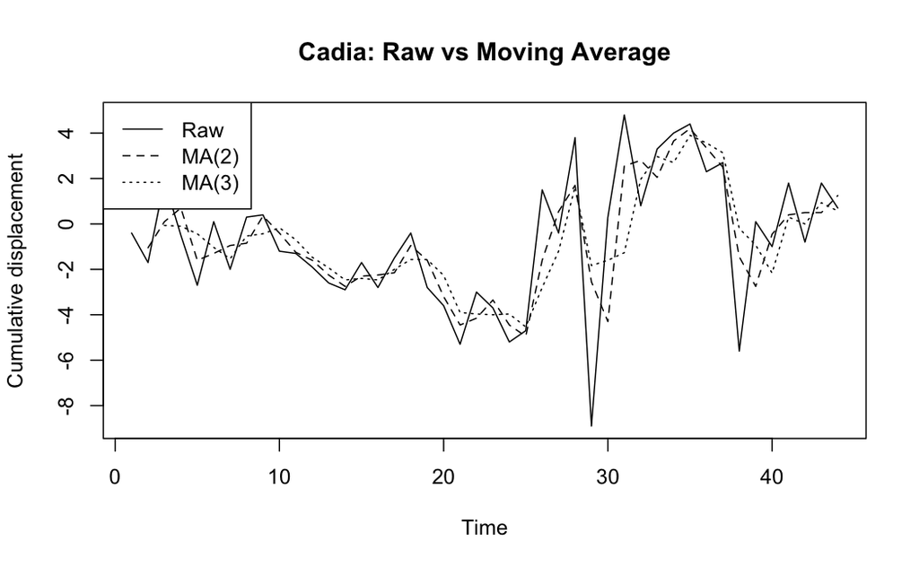

```r
lines(
  1:ncol(cadia_D),
  cadia_MA3[1, ],
  lty = 3
)

legend(
  "topleft",
  legend = c("Raw", "MA(2)", "MA(3)"),
  lty = c(1, 2, 3)
)
```

```r
par(mfrow=c(1,2))

plot(
  as.numeric(peru_D_F[1, ]),
  type = "l",
  xlab = "Time",
  ylab = "Cumulative displacement",
  main = "Peru (F): Raw vs Moving Average"
)

lines(
  1:ncol(peru_D_F),
  peru_F_MA2[1, ],
  lty = 2
)
```

```r
lines(
  1:ncol(peru_D_F),
  peru_F_MA3[1, ],
  lty = 3
)

legend(
  "topleft",
  legend = c("Raw", "MA(2)", "MA(3)"),
  lty = c(1, 2, 3)
)
```

```r
plot(
  as.numeric(peru_D_U[1, ]),
  type = "l",
  xlab = "Time",
  ylab = "Cumulative displacement",
  main = "Peru (U): Raw vs Moving Average"
)

lines(
  1:ncol(peru_D_U),
  peru_U_MA2[1, ],
  lty = 2
)
```

[figure not shown]

```r
lines(
  1:ncol(peru_D_U),
  peru_U_MA3[1, ],
  lty = 3
)

legend(
  "topleft",
  legend = c("Raw", "MA(2)", "MA(3)"),
  lty = c(1, 2, 3)
)
```

```r
png(
  "cadia_raw_vs_MA.png",
  width = 2400,
  height = 1800,
  res = 300
)

plot(
  as.numeric(cadia_D[1, ]),
  type = "l",
  xlab = "Time",
  ylab = "Cumulative displacement",
  main = "Cadia: Raw vs Moving Average"
)

lines(1:ncol(cadia_D), cadia_MA2[1, ], lty = 2)
lines(1:ncol(cadia_D), cadia_MA3[1, ], lty = 3)

legend(
  "topleft",
  legend = c("Raw", "MA(2)", "MA(3)"),
  lty = c(1, 2, 3)
)

dev.off()
```

```r
# Removing the NA values / columns
cadia_MA2 <- cadia_MA2[, -1]
cadia_MA3 <- cadia_MA3[, -c(1:2)]

peru_F_MA2 <- peru_F_MA2[, -1]
peru_F_MA3 <- peru_F_MA3[, -c(1:2)]

peru_U_MA2 <- peru_U_MA2[, -1]
peru_U_MA3 <- peru_U_MA3[, -c(1:2)]
```

### 2.1 Hierarchical Clustering

```r
# Distance matrix w/ Euclidean

# Raw data - Baseline
cadia_dist <- dist(cadia_D, method = "euclidean")
cadia_hc <- hclust(cadia_dist, method = "ward.D2")

# MA(2)
cadia_MA2_dist <- dist(cadia_MA2, method = "euclidean")
cadia_MA2_hc <- hclust(cadia_MA2_dist, method = "ward.D2")

# MA(3)
cadia_MA3_dist <- dist(cadia_MA3, method = "euclidean")
cadia_MA3_hc <- hclust(cadia_MA3_dist, method = "ward.D2")
```

```r
# Raw data - Baseline
peru_F_dist <- dist(peru_D_F, method = "euclidean")
peru_F_hc <- hclust(peru_F_dist, method = "ward.D2")

# MA(2)
peru_F_MA2_dist <- dist(peru_F_MA2, method = "euclidean")
peru_F_MA2_hc <- hclust(peru_F_MA2_dist, method = "ward.D2")

# MA(3)
peru_F_MA3_dist <- dist(peru_F_MA3, method = "euclidean")
peru_F_MA3_hc <- hclust(peru_F_MA3_dist, method = "ward.D2")
```

```r
# Raw data - Baseline
peru_U_dist <- dist(peru_D_U, method = "euclidean")
peru_U_hc <- hclust(peru_U_dist, method = "ward.D2")

# MA(2)
peru_U_MA2_dist <- dist(peru_U_MA2, method = "euclidean")
peru_U_MA2_hc <- hclust(peru_U_MA2_dist, method = "ward.D2")

# MA(3)
peru_U_MA3_dist <- dist(peru_U_MA3, method = "euclidean")
peru_U_MA3_hc <- hclust(peru_U_MA3_dist, method = "ward.D2")
```

#### Dendrograms

```r
plot(cadia_hc, labels = FALSE)
plot(cadia_MA2_hc, labels = FALSE)
plot(cadia_MA3_hc, labels = FALSE)
```

```r
plot(peru_F_hc, labels = FALSE)
plot(peru_F_MA2_hc, labels = FALSE)
plot(peru_F_MA3_hc, labels = FALSE)
```

```r
plot(peru_U_hc, labels = FALSE)
plot(peru_U_MA2_hc, labels = FALSE)
plot(peru_U_MA3_hc, labels = FALSE)
```

#### Silhouette Score

```r
# Average Silhouette Score Helper Function
avg_sil_score <- function(hc, d_mat, k_vals = 2:5){

  avg_sil <- numeric(length(k_vals))

  for(i in seq_along(k_vals)){

    clusters <- cutree(hc, k = k_vals[i])
    sil_score <- silhouette(clusters, d_mat)
    avg_sil[i] <- mean(sil_score[, 3])

  }

  data.frame(
    k = k_vals,
    avg_silhouette_score = avg_sil
  )
}
```

We’ll compute the silhouette score for k = 2, 3, 4 and 5.

```r
# Cadia
cadia_hc_sil <- avg_sil_score(cadia_hc, cadia_dist)

# MA(2)
cadia_MA2_hc_sil <- avg_sil_score(
  cadia_MA2_hc,
  cadia_MA2_dist
)

# MA(3)
cadia_MA3_hc_sil <- avg_sil_score(
  cadia_MA3_hc,
  cadia_MA3_dist
)
```

```r
# ------ Peru (F)
peru_F_hc_sil <- avg_sil_score(peru_F_hc, peru_F_dist)

# MA(2)
peru_F_MA2_hc_sil <- avg_sil_score(
  peru_F_MA2_hc,
  peru_F_MA2_dist
)

# MA(3)
peru_F_MA3_hc_sil <- avg_sil_score(
  peru_F_MA3_hc,
  peru_F_MA3_dist
)

# ------ Peru (U)
peru_U_hc_sil <- avg_sil_score(peru_U_hc, peru_U_dist)

# MA(2)
peru_U_MA2_hc_sil <- avg_sil_score(
  peru_U_MA2_hc,
  peru_U_MA2_dist
)

# MA(3)
peru_U_MA3_hc_sil <- avg_sil_score(
  peru_U_MA3_hc,
  peru_U_MA3_dist
)
```

```r
cadia_hc_sil
cadia_MA2_hc_sil
cadia_MA3_hc_sil
```

```r
peru_F_hc_sil
peru_F_MA2_hc_sil
peru_F_MA3_hc_sil
```

```r
peru_U_hc_sil
peru_U_MA2_hc_sil
peru_U_MA3_hc_sil
```

#### Apply cluster IDs and export

```r
# Cadia - MA(2)
# k = 2
cadia_MA2_hc_2 <- cutree(cadia_MA2_hc, k=2)
table(cadia_MA2_hc_2)
cadia$MA2_hc_2 <- cadia_MA2_hc_2

# k = 3
cadia_MA2_hc_3 <- cutree(cadia_MA2_hc, k=3)
table(cadia_MA2_hc_3)
cadia$MA2_hc_3 <- cadia_MA2_hc_3

# k = 4
cadia_MA2_hc_4 <- cutree(cadia_MA2_hc, k=4)
table(cadia_MA2_hc_4)
cadia$MA2_hc_4 <- cadia_MA2_hc_4

# k = 5
cadia_MA2_hc_5 <- cutree(cadia_MA2_hc, k=5)
table(cadia_MA2_hc_5)
cadia$MA2_hc_5 <- cadia_MA2_hc_5
```

```r
# Cadia - MA(3)
# k = 2
cadia_MA3_hc_2 <- cutree(cadia_MA3_hc, k=2)
table(cadia_MA3_hc_2)
cadia$MA3_hc_2 <- cadia_MA3_hc_2

# k = 3
cadia_MA3_hc_3 <- cutree(cadia_MA3_hc, k=3)
table(cadia_MA3_hc_3)
cadia$MA3_hc_3 <- cadia_MA3_hc_3

# k = 4
cadia_MA3_hc_4 <- cutree(cadia_MA3_hc, k=4)
table(cadia_MA3_hc_4)
cadia$MA3_hc_4 <- cadia_MA3_hc_4

# k = 5
cadia_MA3_hc_5 <- cutree(cadia_MA3_hc, k=5)
table(cadia_MA3_hc_5)
cadia$MA3_hc_5 <- cadia_MA3_hc_5
```

```r
# Peru (F) - MA(2)
# k = 2
peru_F_MA2_hc_2 <- cutree(peru_F_MA2_hc, k=2)
table(peru_F_MA2_hc_2)
peru_failed$MA2_hc_2 <- peru_F_MA2_hc_2

# k = 3
peru_F_MA2_hc_3 <- cutree(peru_F_MA2_hc, k=3)
table(peru_F_MA2_hc_3)
peru_failed$MA2_hc_3 <- peru_F_MA2_hc_3

# k = 4
peru_F_MA2_hc_4 <- cutree(peru_F_MA2_hc, k=4)
table(peru_F_MA2_hc_4)
peru_failed$MA2_hc_4 <- peru_F_MA2_hc_4

# k = 5
peru_F_MA2_hc_5 <- cutree(peru_F_MA2_hc, k=5)
table(peru_F_MA2_hc_5)
peru_failed$MA2_hc_5 <- peru_F_MA2_hc_5
```

```r
# Peru (F) - MA(3)
# k = 2
peru_F_MA3_hc_2 <- cutree(peru_F_MA3_hc, k=2)
table(peru_F_MA3_hc_2)
peru_failed$MA3_hc_2 <- peru_F_MA3_hc_2

# k = 3
peru_F_MA3_hc_3 <- cutree(peru_F_MA3_hc, k=3)
table(peru_F_MA3_hc_3)
peru_failed$MA3_hc_3 <- peru_F_MA3_hc_3

# k = 4
peru_F_MA3_hc_4 <- cutree(peru_F_MA3_hc, k=4)
table(peru_F_MA3_hc_4)
peru_failed$MA3_hc_4 <- peru_F_MA3_hc_4

# k = 5
peru_F_MA3_hc_5 <- cutree(peru_F_MA3_hc, k=5)
table(peru_F_MA3_hc_4)
peru_failed$MA3_hc_5 <- peru_F_MA3_hc_4
```

```r
# Peru (U) - MA(2)
# k = 2
peru_U_MA2_hc_2 <- cutree(peru_U_MA2_hc, k=2)
table(peru_U_MA2_hc_2)
peru_unfailed$MA2_hc_2 <- peru_U_MA2_hc_2

# k = 3
peru_U_MA2_hc_3 <- cutree(peru_U_MA2_hc, k=3)
table(peru_U_MA2_hc_3)
peru_unfailed$MA2_hc_3 <- peru_U_MA2_hc_3

# k = 4
peru_U_MA2_hc_4 <- cutree(peru_U_MA2_hc, k=4)
table(peru_U_MA2_hc_4)
peru_unfailed$MA2_hc_4 <- peru_U_MA2_hc_4

# k = 5
peru_U_MA2_hc_5 <- cutree(peru_U_MA2_hc, k=5)
table(peru_U_MA2_hc_5)
peru_unfailed$MA2_hc_5 <- peru_U_MA2_hc_5
```

```r
# Peru (U) - MA(3)
# k = 2
peru_U_MA3_hc_2 <- cutree(peru_U_MA3_hc, k=2)
table(peru_U_MA3_hc_2)
peru_unfailed$MA3_hc_2 <- peru_U_MA3_hc_2

# k = 3
peru_U_MA3_hc_3 <- cutree(peru_U_MA3_hc, k=3)
table(peru_U_MA3_hc_3)
peru_unfailed$MA3_hc_3 <- peru_U_MA3_hc_3

# k = 4
peru_U_MA3_hc_4 <- cutree(peru_U_MA3_hc, k=4)
table(peru_U_MA3_hc_4)
peru_unfailed$MA3_hc_4 <- peru_U_MA3_hc_4

# k = 5
peru_U_MA3_hc_5 <- cutree(peru_U_MA3_hc, k=5)
table(peru_U_MA3_hc_5)
peru_unfailed$MA3_hc_5 <- peru_U_MA3_hc_5
```

```r
# Export for each case
write.csv(cadia, "cadia_MA_hc.csv", row.names = FALSE)
```

```r
write.csv(peru_failed, "peru_F_MA_hc.csv", row.names = FALSE)
write.csv(peru_unfailed, "peru_U_MA_hc.csv", row.names = FALSE)
```

**Exporting plots**

```r
dend_raw <- as.dendrogram(cadia_hc)
dend_MA2 <- as.dendrogram(cadia_MA2_hc)
dend_MA3 <- as.dendrogram(cadia_MA3_hc)
```

```r
p_raw <- as.ggplot(
  ~ {
    plot(
      dend_raw,
      leaflab = "none",
      main = "Raw",
      ylab = "Height"
    )
  }
)

p_MA2 <- as.ggplot(
  ~ {
    plot(
      dend_MA2,
      leaflab = "none",
      main = "MA(2)",
      ylab = "Height"
    )
  }
)

p_MA3 <- as.ggplot(
  ~ {
    plot(
      dend_MA3,
      leaflab = "none",
      main = "MA(3)",
      ylab = "Height"
    )
  }
)
```

```r
p_cadia_dend_compare <- p_raw + p_MA2 + p_MA3

ggsave(
  "cadia_MA_dendrograms.png",
  p_cadia_dend_compare,
  width = 18,
  height = 5,
  dpi = 300
)
```

### 2.2 K-means clustering

#### Elbow Plot

```r
p_cadia_elbow_raw <- fviz_nbclust(
  cadia_D,
  kmeans,
  method = "wss"
) +
  ggtitle("Cadia: Raw")

p_cadia_elbow_MA2 <- fviz_nbclust(
  cadia_MA2,
  kmeans,
  method = "wss"
) +
  ggtitle("Cadia: MA(2)")

p_cadia_elbow_MA3 <- fviz_nbclust(
  cadia_MA3,
  kmeans,
  method = "wss"
) +
  ggtitle("Cadia: MA(3)")
```

```r
ggsave(
  "cadia_elbow_raw.png",
  p_cadia_elbow_raw,
  width = 7,
  height = 5,
  dpi = 300
)
ggsave(
  "cadia_elbow_MA2.png",
  p_cadia_elbow_MA2,
  width = 7,
  height = 5,
  dpi = 300
)
ggsave(
  "cadia_elbow_MA3.png",
  p_cadia_elbow_MA3,
  width = 7,
  height = 5,
  dpi = 300
)
```

```r
p_peru_F_elbow_raw <- fviz_nbclust(
  peru_D_F,
  kmeans,
  method = "wss"
) +
  ggtitle("Peru (F): Raw")

p_peru_F_elbow_MA2 <- fviz_nbclust(
  peru_F_MA2,
  kmeans,
  method = "wss"
) +
  ggtitle("Peru (F): MA(2)")

p_peru_F_elbow_MA3 <- fviz_nbclust(
  peru_F_MA3,
  kmeans,
  method = "wss"
) +
  ggtitle("Peru (F): MA(3)")
```

```r
ggsave(
  "peru_F_elbow_raw.png",
  p_peru_F_elbow_raw,
  width = 7,
  height = 5,
  dpi = 300
)
ggsave(
  "peru_F_elbow_MA2.png",
  p_peru_F_elbow_MA2,
  width = 7,
  height = 5,
  dpi = 300
)
ggsave(
  "peru_F_elbow_MA3.png",
  p_peru_F_elbow_MA3,
  width = 7,
  height = 5,
  dpi = 300
)
```

```r
p_peru_U_elbow_raw <- fviz_nbclust(
  peru_D_U,
  kmeans,
  method = "wss"
) +
  ggtitle("Peru (U): Raw")

p_peru_U_elbow_MA2 <- fviz_nbclust(
  peru_U_MA2,
  kmeans,
  method = "wss"
) +
  ggtitle("Peru (U): MA(2)")

p_peru_U_elbow_MA3 <- fviz_nbclust(
  peru_U_MA3,
  kmeans,
  method = "wss"
) +
  ggtitle("Peru (U): MA(3)")
```

```r
ggsave(
  "peru_U_elbow_raw.png",
  p_peru_U_elbow_raw,
  width = 7,
  height = 5,
  dpi = 300
)
ggsave(
  "peru_U_elbow_MA2.png",
  p_peru_U_elbow_MA2,
  width = 7,
  height = 5,
  dpi = 300
)
ggsave(
  "peru_U_elbow_MA3.png",
  p_peru_U_elbow_MA3,
  width = 7,
  height = 5,
  dpi = 300
)
```

#### Silhouette Score Plot

```r
fviz_nbclust(cadia_D, kmeans, method = "silhouette") + ggtitle("Optimal number of clusters: Cadia")

fviz_nbclust(cadia_MA2, kmeans, method = "silhouette") + ggtitle("Optimal number of clusters: Cadia")

fviz_nbclust(cadia_MA3, kmeans, method = "silhouette") + ggtitle("Optimal number of clusters: Cadia")
```

```r
p_cadia_sil_raw <- fviz_nbclust(
  cadia_D,
  kmeans,
  method = "silhouette"
) +
  ggtitle("Cadia: Raw")

p_cadia_sil_MA2 <- fviz_nbclust(
  cadia_MA2,
  kmeans,
  method = "silhouette"
) +
  ggtitle("Cadia: MA(2)")

p_cadia_sil_MA3 <- fviz_nbclust(
  cadia_MA3,
  kmeans,
  method = "silhouette"
) +
  ggtitle("Cadia: MA(3)")
```

```r
ggsave("cadia_sil_raw.png",
       p_cadia_sil_raw, width = 7, height = 5, dpi = 300)

ggsave("cadia_sil_MA2.png",
       p_cadia_sil_MA2, width = 7, height = 5, dpi = 300)

ggsave("cadia_sil_MA3.png",
       p_cadia_sil_MA3, width = 7, height = 5, dpi = 300)
```

```r
p_peru_F_sil_raw <- fviz_nbclust(
  peru_D_F,
  kmeans,
  method = "silhouette"
) +
  ggtitle("Peru (F): Raw")

p_peru_F_sil_MA2 <- fviz_nbclust(
  peru_F_MA2,
  kmeans,
  method = "silhouette"
) +
  ggtitle("Peru (F): MA(2)")

p_peru_F_sil_MA3 <- fviz_nbclust(
  peru_F_MA3,
  kmeans,
  method = "silhouette"
) +
  ggtitle("Peru (F): MA(3)")
```

```r
ggsave("peru_F_sil_raw.png",
       p_peru_F_sil_raw, width = 7, height = 5, dpi = 300)

ggsave("peru_F_sil_MA2.png",
       p_peru_F_sil_MA3, width = 7, height = 5, dpi = 300)

ggsave("peru_F_sil_MA3.png",
       p_peru_F_sil_MA3, width = 7, height = 5, dpi = 300)
```

```r
p_peru_U_sil_raw <- fviz_nbclust(
  peru_D_U,
  kmeans,
  method = "silhouette"
) +
  ggtitle("Peru (U): Raw")

p_peru_U_sil_MA2 <- fviz_nbclust(
  peru_U_MA2,
  kmeans,
  method = "silhouette"
) +
  ggtitle("Peru (U): MA(2)")

p_peru_U_sil_MA3 <- fviz_nbclust(
  peru_U_MA3,
  kmeans,
  method = "silhouette"
) +
  ggtitle("Peru (U): MA(3)")
```

```r
ggsave("peru_U_sil_raw.png",
       p_peru_U_sil_raw, width = 7, height = 5, dpi = 300)

ggsave("peru_U_sil_MA2.png",
       p_peru_U_sil_MA3, width = 7, height = 5, dpi = 300)

ggsave("peru_U_sil_MA3.png",
       p_peru_U_sil_MA3, width = 7, height = 5, dpi = 300)
```

#### Applying K-means clustering

```r
set.seed(1234)

# Raw
cadia_km_2 <- kmeans(cadia_D, centers = 2, nstart = 20)
cadia_km_3 <- kmeans(cadia_D, centers = 3, nstart = 20)
cadia_km_4 <- kmeans(cadia_D, centers = 4, nstart = 20)
cadia_km_5 <- kmeans(cadia_D, centers = 5, nstart = 20)

# MA(2)
cadia_MA2_km_2 <- kmeans(cadia_MA2, centers = 2, nstart = 20)
cadia_MA2_km_3 <- kmeans(cadia_MA2, centers = 3, nstart = 20)
cadia_MA2_km_4 <- kmeans(cadia_MA2, centers = 4, nstart = 20)
cadia_MA2_km_5 <- kmeans(cadia_MA2, centers = 5, nstart = 20)

# MA(3)
cadia_MA3_km_2 <- kmeans(cadia_MA3, centers = 2, nstart = 20)
cadia_MA3_km_3 <- kmeans(cadia_MA3, centers = 3, nstart = 20)
cadia_MA3_km_4 <- kmeans(cadia_MA3, centers = 4, nstart = 20)
cadia_MA3_km_5 <- kmeans(cadia_MA3, centers = 5, nstart = 20)
```

```r
set.seed(1234)

# Raw
peru_F_km_2 <- kmeans(peru_D_F, centers = 2, nstart = 20)
peru_F_km_3 <- kmeans(peru_D_F, centers = 3, nstart = 20)
peru_F_km_4 <- kmeans(peru_D_F, centers = 4, nstart = 20)
peru_F_km_5 <- kmeans(peru_D_F, centers = 5, nstart = 20)

# MA(2)
peru_F_MA2_km_2 <- kmeans(peru_F_MA2, centers = 2, nstart = 20)
peru_F_MA2_km_3 <- kmeans(peru_F_MA2, centers = 3, nstart = 20)
peru_F_MA2_km_4 <- kmeans(peru_F_MA2, centers = 4, nstart = 20)
peru_F_MA2_km_5 <- kmeans(peru_F_MA2, centers = 5, nstart = 20)

# MA(3)
peru_F_MA3_km_2 <- kmeans(peru_F_MA3, centers = 2, nstart = 20)
peru_F_MA3_km_3 <- kmeans(peru_F_MA3, centers = 3, nstart = 20)
peru_F_MA3_km_4 <- kmeans(peru_F_MA3, centers = 4, nstart = 20)
peru_F_MA3_km_5 <- kmeans(peru_F_MA3, centers = 5, nstart = 20)
```

```r
set.seed(1234)

# Raw
peru_U_km_2 <- kmeans(peru_D_U, centers = 2, nstart = 20)
peru_U_km_3 <- kmeans(peru_D_U, centers = 3, nstart = 20)
peru_U_km_4 <- kmeans(peru_D_U, centers = 4, nstart = 20)
peru_U_km_5 <- kmeans(peru_D_U, centers = 5, nstart = 20)

# MA(2)
peru_U_MA2_km_2 <- kmeans(peru_U_MA2, centers = 2, nstart = 20)
peru_U_MA2_km_3 <- kmeans(peru_U_MA2, centers = 3, nstart = 20)
peru_U_MA2_km_4 <- kmeans(peru_U_MA2, centers = 4, nstart = 20)
peru_U_MA2_km_5 <- kmeans(peru_U_MA2, centers = 5, nstart = 20)

# MA(3)
peru_U_MA3_km_2 <- kmeans(peru_U_MA3, centers = 2, nstart = 20)
peru_U_MA3_km_3 <- kmeans(peru_U_MA3, centers = 3, nstart = 20)
peru_U_MA3_km_4 <- kmeans(peru_U_MA3, centers = 4, nstart = 20)
peru_U_MA3_km_5 <- kmeans(peru_U_MA3, centers = 5, nstart = 20)
```

#### Silhouette Score

```r
# Helper function for K-means
avg_sil_score_km <- function(km_models, d_mat){

  avg_sil <- numeric(length(km_models))

  for(i in seq_along(km_models)){

    sil_score <- silhouette(
      km_models[[i]]$cluster,
      d_mat
    )

    avg_sil[i] <- mean(sil_score[,3])

  }

  data.frame(
    k = 2:5,
    avg_silhouette_score = avg_sil
  )

}
```

```r
cadia_km_sil <- avg_sil_score_km(
  list(cadia_km_2,
       cadia_km_3,
       cadia_km_4,
       cadia_km_5),
  cadia_dist
)

cadia_MA2_km_sil <- avg_sil_score_km(
  list(cadia_MA2_km_2,
       cadia_MA2_km_3,
       cadia_MA2_km_4,
       cadia_MA2_km_5),
  cadia_MA2_dist
)

cadia_MA3_km_sil <- avg_sil_score_km(
  list(cadia_MA3_km_2,
       cadia_MA3_km_3,
       cadia_MA3_km_4,
       cadia_MA3_km_5),
  cadia_MA3_dist
)
```

```r
peru_F_km_sil <- avg_sil_score_km(
  list(peru_F_km_2,
       peru_F_km_3,
       peru_F_km_4,
       peru_F_km_5),
  peru_F_dist
)

peru_F_MA2_km_sil <- avg_sil_score_km(
  list(peru_F_MA2_km_2,
       peru_F_MA2_km_3,
       peru_F_MA2_km_4,
       peru_F_MA2_km_5),
  peru_F_MA2_dist
)

peru_F_MA3_km_sil <- avg_sil_score_km(
  list(peru_F_MA3_km_2,
       peru_F_MA3_km_3,
       peru_F_MA3_km_4,
       peru_F_MA3_km_5),
  peru_F_MA3_dist
)
```

```r
peru_U_km_sil <- avg_sil_score_km(
  list(peru_U_km_2,
       peru_U_km_3,
       peru_U_km_4,
       peru_U_km_5),
  peru_U_dist
)

peru_U_MA2_km_sil <- avg_sil_score_km(
  list(peru_U_MA2_km_2,
       peru_U_MA2_km_3,
       peru_U_MA2_km_4,
       peru_U_MA2_km_5),
  peru_U_MA2_dist
)

peru_U_MA3_km_sil <- avg_sil_score_km(
  list(peru_U_MA3_km_2,
       peru_U_MA3_km_3,
       peru_U_MA3_km_4,
       peru_U_MA3_km_5),
  peru_U_MA3_dist
)
```

**Average Silhouette Score Results**

```r
cadia_km_sil
cadia_MA2_km_sil
cadia_MA3_km_sil
```

```r
peru_F_km_sil
peru_F_MA2_km_sil
peru_F_MA3_km_sil
```

```r
peru_U_km_sil
peru_U_MA2_km_sil
peru_U_MA3_km_sil
```

#### Davies-Bouldin Index

```r
# Davies-Bouldin Index Helper function
dbi_km <- function(data, km_models, k_vals = 2:5) {

  db_vals <- numeric(length(km_models))

  for (i in seq_along(k_vals)) {
    db_vals[i] <- index.DB(
      data,
      km_models[[i]]$cluster
    )$DB
  }

  data.frame(
    k = k_vals,
    davies_bouldin = db_vals
  )
}
```

```r
cadia_km_db <- dbi_km(
  cadia_D,
  list(cadia_km_2,
       cadia_km_3,
       cadia_km_4,
       cadia_km_5)
)

cadia_MA2_km_db <- dbi_km(
  cadia_MA2,
  list(cadia_MA2_km_2,
       cadia_MA2_km_3,
       cadia_MA2_km_4,
       cadia_MA2_km_5)
)

cadia_MA3_km_db <- dbi_km(
  cadia_MA3,
  list(cadia_MA3_km_2,
       cadia_MA3_km_3,
       cadia_MA3_km_4,
       cadia_MA3_km_5)
)
```

```r
peru_F_km_db <- dbi_km(
  peru_D_F,
  list(peru_F_km_2,
       peru_F_km_3,
       peru_F_km_4,
       peru_F_km_5)
)

peru_F_MA2_km_db <- dbi_km(
  peru_F_MA2,
  list(peru_F_MA2_km_2,
       peru_F_MA2_km_3,
       peru_F_MA2_km_4,
       peru_F_MA2_km_5)
)

peru_F_MA3_km_db <- dbi_km(
  peru_F_MA3,
  list(peru_F_MA3_km_2,
       peru_F_MA3_km_3,
       peru_F_MA3_km_4,
       peru_F_MA3_km_5)
)
```

```r
peru_U_km_db <- dbi_km(
  peru_D_U,
  list(peru_U_km_2,
       peru_U_km_3,
       peru_U_km_4,
       peru_U_km_5)
)

peru_U_MA2_km_db <- dbi_km(
  peru_U_MA2,
  list(peru_U_MA2_km_2,
       peru_U_MA2_km_3,
       peru_U_MA2_km_4,
       peru_U_MA2_km_5)
)

peru_U_MA3_km_db <- dbi_km(
  peru_U_MA3,
  list(peru_U_MA3_km_2,
       peru_U_MA3_km_3,
       peru_U_MA3_km_4,
       peru_U_MA3_km_5)
)
```

```r
cadia_km_db
cadia_MA2_km_db
cadia_MA3_km_db
```

```r
peru_F_km_db
peru_F_MA2_km_db
peru_F_MA3_km_db
```

```r
peru_U_km_db
peru_U_MA2_km_db
peru_U_MA3_km_db
```

```r
p_db_cadia <- ggplot(
  cadia_km_db,
  aes(
    x = k,
    y = davies_bouldin
  )
) +
  geom_line() +
  geom_point(size = 2.5) +
  scale_x_continuous(breaks = 2:5) +
  labs(
    title = "Davies–Bouldin Index: Cadia (Raw)",
    x = "Number of clusters",
    y = "Davies–Bouldin index"
  ) +
  theme_minimal()

p_db_cadia_MA2 <- ggplot(
  cadia_MA2_km_db,
  aes(
    x = k,
    y = davies_bouldin
  )
) +
  geom_line() +
  geom_point(size = 2.5) +
  scale_x_continuous(breaks = 2:5) +
  labs(
    title = "Davies–Bouldin Index: Cadia (MA2)",
    x = "Number of clusters",
    y = "Davies–Bouldin index"
  ) +
  theme_minimal()

p_db_cadia_MA3 <- ggplot(
  cadia_MA3_km_db,
  aes(
    x = k,
    y = davies_bouldin
  )
) +
  geom_line() +
  geom_point(size = 2.5) +
  scale_x_continuous(breaks = 2:5) +
  labs(
    title = "Davies–Bouldin Index: Cadia (MA3)",
    x = "Number of clusters",
    y = "Davies–Bouldin index"
  ) +
  theme_minimal()
```

```r
ggsave(
  "cadia_dbi_piecewise_raw.png",
  p_db_cadia,
  width = 7,
  height = 5,
  dpi = 300
)
```

```r
ggsave(
  "cadia_dbi_piecewise_MA2.png",
  p_db_cadia_MA2,
  width = 7,
  height = 5,
  dpi = 300
)
```

```r
ggsave(
  "cadia_dbi_piecewise_MA3.png",
  p_db_cadia_MA3,
  width = 7,
  height = 5,
  dpi = 300
)
```

```r
# Peru (F) -------
p_db_peru_F <- ggplot(
  peru_F_km_db,
  aes(
    x = k,
    y = davies_bouldin
  )
) +
  geom_line() +
  geom_point(size = 2.5) +
  scale_x_continuous(breaks = 2:5) +
  labs(
    title = "Davies–Bouldin Index: Peru - Failed (Raw)",
    x = "Number of clusters",
    y = "Davies–Bouldin index"
  ) +
  theme_minimal()

p_db_peru_F_MA2 <- ggplot(
  peru_F_MA2_km_db,
  aes(
    x = k,
    y = davies_bouldin
  )
) +
  geom_line() +
  geom_point(size = 2.5) +
  scale_x_continuous(breaks = 2:5) +
  labs(
    title = "Davies–Bouldin Index: Peru - Failed (MA2)",
    x = "Number of clusters",
    y = "Davies–Bouldin index"
  ) +
  theme_minimal()

p_db_peru_F_MA3 <- ggplot(
  peru_F_MA3_km_db,
  aes(
    x = k,
    y = davies_bouldin
  )
) +
  geom_line() +
  geom_point(size = 2.5) +
  scale_x_continuous(breaks = 2:5) +
  labs(
    title = "Davies–Bouldin Index: Peru - Failed (MA3)",
    x = "Number of clusters",
    y = "Davies–Bouldin index"
  ) +
  theme_minimal()
```

```r
# Export Peru (F) DBI Plots
ggsave(
  "peru_F_dbi_piecewise_raw.png",
  p_db_peru_F,
  width = 7,
  height = 5,
  dpi = 300
)

ggsave(
  "peru_F_dbi_piecewise_MA2.png",
  p_db_peru_F_MA2,
  width = 7,
  height = 5,
  dpi = 300
)

ggsave(
  "peru_F_dbi_piecewise_MA3.png",
  p_db_peru_F_MA3,
  width = 7,
  height = 5,
  dpi = 300
)
```

```r
# Peru (U) -------
p_db_peru_U <- ggplot(
  peru_U_km_db,
  aes(
    x = k,
    y = davies_bouldin
  )
) +
  geom_line() +
  geom_point(size = 2.5) +
  scale_x_continuous(breaks = 2:5) +
  labs(
    title = "Davies–Bouldin Index: Peru - Unfailed (Raw)",
    x = "Number of clusters",
    y = "Davies–Bouldin index"
  ) +
  theme_minimal()

p_db_peru_U_MA2 <- ggplot(
  peru_U_MA2_km_db,
  aes(
    x = k,
    y = davies_bouldin
  )
) +
  geom_line() +
  geom_point(size = 2.5) +
  scale_x_continuous(breaks = 2:5) +
  labs(
    title = "Davies–Bouldin Index: Peru - Unfailed (MA2)",
    x = "Number of clusters",
    y = "Davies–Bouldin index"
  ) +
  theme_minimal()

p_db_peru_U_MA3 <- ggplot(
  peru_U_MA3_km_db,
  aes(
    x = k,
    y = davies_bouldin
  )
) +
  geom_line() +
  geom_point(size = 2.5) +
  scale_x_continuous(breaks = 2:5) +
  labs(
    title = "Davies–Bouldin Index: Peru - Unfailed (MA3)",
    x = "Number of clusters",
    y = "Davies–Bouldin index"
  ) +
  theme_minimal()
```

```r
# Export Peru (U) DBI Plots
ggsave(
  "peru_U_dbi_piecewise_raw.png",
  p_db_peru_U,
  width = 7,
  height = 5,
  dpi = 300
)

ggsave(
  "peru_U_dbi_piecewise_MA2.png",
  p_db_peru_U_MA2,
  width = 7,
  height = 5,
  dpi = 300
)

ggsave(
  "peru_U_dbi_piecewise_MA3.png",
  p_db_peru_U_MA3,
  width = 7,
  height = 5,
  dpi = 300
)
```

#### Apply cluster IDs and export

```r
# MA(2) K-means cluster IDs
cadia$MA2_km_2 <- cadia_MA2_km_2$cluster
cadia$MA2_km_3 <- cadia_MA2_km_3$cluster
cadia$MA2_km_4 <- cadia_MA2_km_4$cluster
cadia$MA2_km_5 <- cadia_MA2_km_5$cluster

# MA(3)
cadia$MA3_km_2 <- cadia_MA3_km_2$cluster
cadia$MA3_km_3 <- cadia_MA3_km_3$cluster
cadia$MA3_km_4 <- cadia_MA3_km_4$cluster
cadia$MA3_km_5 <- cadia_MA3_km_5$cluster


write.csv(
  cadia,
  "cadia_MA_km.csv",
  row.names = FALSE
)
```

```r
# Peru (F)
# MA(2) K-means cluster IDs
peru_failed$MA2_km_2 <- peru_F_MA2_km_2$cluster
peru_failed$MA2_km_3 <- peru_F_MA2_km_3$cluster
peru_failed$MA2_km_4 <- peru_F_MA2_km_4$cluster
peru_failed$MA2_km_5 <- peru_F_MA2_km_5$cluster

# MA(3)
peru_failed$MA3_km_2 <- peru_F_MA3_km_2$cluster
peru_failed$MA3_km_3 <- peru_F_MA3_km_3$cluster
peru_failed$MA3_km_4 <- peru_F_MA3_km_4$cluster
peru_failed$MA3_km_5 <- peru_F_MA3_km_5$cluster


write.csv(
  peru_failed,
  "peru_F_MA_km.csv",
  row.names = FALSE
)
```

```r
# Peru (U)
# MA(2) K-means cluster IDs
peru_unfailed$MA2_km_2 <- peru_U_MA2_km_2$cluster
peru_unfailed$MA2_km_3 <- peru_U_MA2_km_3$cluster
peru_unfailed$MA2_km_4 <- peru_U_MA2_km_4$cluster
peru_unfailed$MA2_km_5 <- peru_U_MA2_km_5$cluster

# MA(3)
peru_unfailed$MA3_km_2 <- peru_U_MA3_km_2$cluster
peru_unfailed$MA3_km_3 <- peru_U_MA3_km_3$cluster
peru_unfailed$MA3_km_4 <- peru_U_MA3_km_4$cluster
peru_unfailed$MA3_km_5 <- peru_U_MA3_km_5$cluster


write.csv(
  peru_unfailed,
  "peru_U_MA_km.csv",
  row.names = FALSE
)
```

## 3. Piecewise Linear Regression

As clustering can be strongly influenced by displacement magnitude and fluctuations, we continue to test methods that smooth out and work with outliers.

The spline approach represents each time series by its rate of deformation over successive time intervals. It may be able to identify and distinguish different deformation behaviours based on changes in velocity/slope.

We’ll use the data represented in matrices that still include the baseline date with 0 to use for the first slope.

```r
dim(cadia_D_mat)
dim(peru_D_F_mat)
dim(peru_D_U_mat)
```

```r
# Extracting actual date names
  # note that all dates are from a descending orbit track

cadia_dates <- as.Date(sub("D_", "", colnames(cadia_D_mat)), format = "%Y%m%d")

cadia_dates
```

Piecewise linear models partition the data into segments and fit separate linear regression models to each segment. It allows for broad average trends in the data to be captured while maintaining simplicity and interpretability.

Each segment is divided to make almost linear sections. An index feature is used to model the marginal change of one unit of time. When a series has break points in the trend, we add a knot to each break point:

- A knot feature allows us to inform the model of a change in the trend slope.
- Left to the knot point equals 0, right to the knot is an arbitrage numbers that increase as a function of time.

Instead of treating the columns as observations 1, 2, 3…, we will use elapsed days: 0, 12, 24, 36, 60, etc.

```r
cadia_time <- as.numeric(cadia_dates - cadia_dates[1])

cadia_time
```

```r
diff(cadia_dates)
```

```r
# Peru F
peru_F_dates <- as.Date(
  sub("D_", "", colnames(peru_D_F_mat)),
  format = "%Y%m%d"
)

peru_F_time <- as.numeric(
  peru_F_dates - peru_F_dates[1]
)

diff(peru_F_dates)
```

We choose fixed knots, initially testing 60-day intervals (and the satellite capturing measurements in 12-day intervals).

Define our knots:

```r
cadia_knots <- seq(60, max(cadia_time) - 60, by = 60)

cadia_knots
```

```r
# peru F
peru_F_knots <- seq(
  60,
  max(peru_F_time) - 60,
  by = 60
)
```

```r
# Apply spline regression

y <- cadia_D_mat[1, ]

X <- data.frame(time = cadia_time)

for(k in cadia_knots) {
  X[[paste0("knot_", k)]] <- pmax(0, cadia_time - k)
}

cadia_model_data <- cbind(data.frame(displacement = y), X)

cadia_test_fit <- lm(displacement ~ ., data = cadia_model_data)
```

```r
png(
  "cadia_piecewise_dendrogram.png",
  width = 2400,
  height = 1800,
  res = 300
)

plot(
  cadia_dates,
  y,
  type = "o",
  xlab = "Date",
  ylab = "Cumulative displacement (mm)",
  main = "Cadia: Piecewise Linear Fit"
)

lines(
  cadia_dates,
  fitted(cadia_test_fit),
  lwd = 2
)

abline(
  v = cadia_dates[1] + cadia_knots,
  lty = 2
)

dev.off()
```

Extracting the slopes from the fitted model for clustering:

```r
cadia_coefs <- coef(cadia_test_fit)

cadia_coefs
```

```r
# Remove intercept
cadia_slope_changes <- cadia_coefs[-1]

# convert slope changes into actual slope for each interval
cadia_test_slopes <- cumsum(cadia_slope_changes)

cadia_test_slopes
```

```r
# ^^^^ Process as a function

extract_piecewise_slopes <- function(displacement, time, knots) {

  # Design matrix
  X <- data.frame(time = time)

  for(k in knots) {
    X[[paste0("knot_", k)]] <- pmax(0, time - k)
  }

  # Add displacement
  model_data <- cbind(
    data.frame(displacement = displacement),
    X
  )

  # Fit continuous piecewise-linear regression
  fit <- lm(
    displacement ~ .,
    data = model_data
  )

  # Remove intercept
  slope_changes <- coef(fit)[-1]

  # Actual slope in each interval
  interval_slopes <- cumsum(slope_changes)

  names(interval_slopes) <- paste0(
    "Slope_", seq_along(interval_slopes)
  )

  return(interval_slopes)
}
```

```r
test_slopes <- extract_piecewise_slopes(
  displacement = cadia_D_mat[1, ],
  time = cadia_time,
  knots = cadia_knots
)

test_slopes
```

```r
peru_F_piecewise <- t(
  apply(
    peru_D_F_mat,
    1,
    extract_piecewise_slopes,
    time = peru_F_time,
    knots = peru_F_knots
  )
)

dim(peru_F_piecewise)
anyNA(peru_F_piecewise)
```

```r
cadia_test_slopes
```

```r
# apply to every cadia ob

cadia_piecewise <- t(apply(cadia_D_mat, 1, extract_piecewise_slopes, time = cadia_time, knots = cadia_knots))
```

```r
dim(cadia_piecewise)

head(cadia_piecewise)

anyNA(cadia_piecewise)
```

We’ve converted the original data from 12502 x 45 displacement values to 12502 x ~9 slope values.

```r
peru_U_dates <- as.Date(
  sub("D_", "", colnames(peru_D_U_mat)),
  format = "%Y%m%d"
)

peru_U_time <- as.numeric(
  peru_U_dates - peru_U_dates[1]
)

peru_U_knots <- seq(
  60,
  max(peru_U_time) - 60,
  by = 60
)

peru_U_piecewise <- t(
  apply(
    peru_D_U_mat,
    1,
    extract_piecewise_slopes,
    time = peru_U_time,
    knots = peru_U_knots
  )
)

anyNA(peru_U_piecewise)
```

### 3.1 Hierarchical Clustering

```r
# Cadia

cadia_piecewise_dist <- dist(cadia_piecewise, method = "euclidean")

cadia_piecewise_hc <- hclust(cadia_piecewise_dist, method = "ward.D2")
```

#### Dendrograms

```r
plot(cadia_piecewise_hc, labels = FALSE)
```

```r
png(
  "cadia_piecewise_dendrogram2.png",
  width = 2400,
  height = 1800,
  res = 300
)

plot(
  cadia_piecewise_hc,
  labels = FALSE,
  main = "Cadia: Piecewise Linear Regression",
  xlab = "",
  sub = "",
  ylab = "Height"
)

dev.off()
```

##### Peru

```r
peru_F_piecewise_dist <- dist(
  peru_F_piecewise,
  method = "euclidean"
)

peru_F_piecewise_hc <- hclust(
  peru_F_piecewise_dist,
  method = "ward.D2"
)

peru_F_piecewise_hc_sil <- avg_sil_score(
  peru_F_piecewise_hc,
  peru_F_piecewise_dist
)

peru_F_piecewise_hc_sil
```

```r
# memberships
peru_failed$piecewise_hc_2 <- cutree(peru_F_piecewise_hc, k = 2)
peru_failed$piecewise_hc_3 <- cutree(peru_F_piecewise_hc, k = 3)
peru_failed$piecewise_hc_4 <- cutree(peru_F_piecewise_hc, k = 4)
peru_failed$piecewise_hc_5 <- cutree(peru_F_piecewise_hc, k = 5)
```

```r
# Peru unfailed
peru_U_piecewise_dist <- dist(peru_U_piecewise)

peru_U_piecewise_hc <- hclust(
  peru_U_piecewise_dist,
  method = "ward.D2"
)

peru_U_piecewise_hc_sil <- avg_sil_score(
  peru_U_piecewise_hc,
  peru_U_piecewise_dist
)

peru_U_piecewise_hc_sil

peru_unfailed$piecewise_hc_2 <- cutree(peru_U_piecewise_hc, k = 2)
peru_unfailed$piecewise_hc_3 <- cutree(peru_U_piecewise_hc, k = 3)
peru_unfailed$piecewise_hc_4 <- cutree(peru_U_piecewise_hc, k = 4)
peru_unfailed$piecewise_hc_5 <- cutree(peru_U_piecewise_hc, k = 5)
```

#### Silhouette Score

```r
cadia_piecewise_hc_sil <- avg_sil_score(
  cadia_piecewise_hc,
  cadia_piecewise_dist
)

cadia_piecewise_hc_sil
```

#### Apply cluster IDs and export

```r
# Cadia
# k = 2
cadia_piecwise_hc_2 <- cutree(cadia_piecewise_hc, k=2)
table(cadia_piecwise_hc_2)
cadia$piecewise_hc_2 <- cadia_piecwise_hc_2

# k = 3
cadia_piecwise_hc_3 <- cutree(cadia_piecewise_hc, k=3)
table(cadia_piecwise_hc_3)
cadia$piecewise_hc_3 <- cadia_piecwise_hc_3

# k = 4
cadia_piecwise_hc_4 <- cutree(cadia_piecewise_hc, k=4)
table(cadia_piecwise_hc_4)
cadia$piecewise_hc_4 <- cadia_piecwise_hc_4

# k = 5
cadia_piecwise_hc_5 <- cutree(cadia_piecewise_hc, k=5)
table(cadia_piecwise_hc_5)
cadia$piecewise_hc_5 <- cadia_piecwise_hc_5
```

```r
# Export for each case
write.csv(cadia, "cadia_piece_wise_hc.csv", row.names = FALSE)
```

### 3.2 K-means clustering

#### Elbow Plot

```r
fviz_nbclust(cadia_D, kmeans, method = "wss") + ggtitle("Optimal number of clusters: Cadia (Raw)")
fviz_nbclust(cadia_piecewise, kmeans, method = "wss") + ggtitle("Optimal number of clusters: Cadia Piecewise")
```

```r
p_cadia_elbow_pw <- fviz_nbclust(
  cadia_piecewise,
  kmeans,
  method = "wss"
) +
  ggtitle("Cadia: Piecewise Linear Regression")
```

```r
ggsave(
  "cadia_elbow_pw.png",
  p_cadia_elbow_pw,
  width = 7,
  height = 5,
  dpi = 300
)
```

#### Silhouette Score Plot

```r
fviz_nbclust(cadia_D, kmeans, method = "silhouette") + ggtitle("Optimal number of clusters: Cadia")

fviz_nbclust(cadia_piecewise, kmeans, method = "silhouette") + ggtitle("Optimal number of clusters: Cadia")
```

```r
p_cadia_sil_pw <- fviz_nbclust(
  cadia_piecewise,
  kmeans,
  method = "silhouette"
) +
  ggtitle("Cadia: Piecewise Linear Regression")
```

```r
ggsave("cadia_sil_pw.png",
       p_cadia_sil_pw, width = 7, height = 5, dpi = 300)
```

#### Applying K-means clustering

```r
set.seed(1234)

cadia_piecewise_km_2 <- kmeans(
  cadia_piecewise,
  centers = 2,
  nstart = 20
)

cadia_piecewise_km_3 <- kmeans(
  cadia_piecewise,
  centers = 3,
  nstart = 20
)

cadia_piecewise_km_4 <- kmeans(
  cadia_piecewise,
  centers = 4,
  nstart = 20
)

cadia_piecewise_km_5 <- kmeans(
  cadia_piecewise,
  centers = 5,
  nstart = 20
)
```

```r
set.seed(1234)

peru_F_piecewise_km_2 <- kmeans(peru_F_piecewise, centers = 2, nstart = 20)
peru_F_piecewise_km_3 <- kmeans(peru_F_piecewise, centers = 3, nstart = 20)
peru_F_piecewise_km_4 <- kmeans(peru_F_piecewise, centers = 4, nstart = 20)
peru_F_piecewise_km_5 <- kmeans(peru_F_piecewise, centers = 5, nstart = 20)
```

```r
set.seed(1234)

peru_U_piecewise_km_2 <- kmeans(peru_U_piecewise, 2, nstart = 20)
peru_U_piecewise_km_3 <- kmeans(peru_U_piecewise, 3, nstart = 20)
peru_U_piecewise_km_4 <- kmeans(peru_U_piecewise, 4, nstart = 20)
peru_U_piecewise_km_5 <- kmeans(peru_U_piecewise, 5, nstart = 20)

peru_U_piecewise_km_sil <- avg_sil_score_km(
  list(
    peru_U_piecewise_km_2,
    peru_U_piecewise_km_3,
    peru_U_piecewise_km_4,
    peru_U_piecewise_km_5
  ),
  peru_U_piecewise_dist
)

peru_U_piecewise_km_db <- dbi_km(
  peru_U_piecewise,
  list(
    peru_U_piecewise_km_2,
    peru_U_piecewise_km_3,
    peru_U_piecewise_km_4,
    peru_U_piecewise_km_5
  )
)

peru_U_piecewise_km_sil
peru_U_piecewise_km_db
```

#### Silhouette Score

```r
cadia_piecewise_km_sil <- avg_sil_score_km(
  list(cadia_piecewise_km_2,
       cadia_piecewise_km_3,
       cadia_piecewise_km_4,
       cadia_piecewise_km_5),
  cadia_piecewise_dist
)
```

```r
peru_F_piecewise_km_sil <- avg_sil_score_km(
  list(
    peru_F_piecewise_km_2,
    peru_F_piecewise_km_3,
    peru_F_piecewise_km_4,
    peru_F_piecewise_km_5
  ),
  peru_F_piecewise_dist
)

peru_F_piecewise_km_sil
```

```r
#cadia_km_sil
cadia_piecewise_km_sil
```

#### Davies-Bouldin Index

```r
cadia_piecewise_km_db <- dbi_km(
  cadia_piecewise,
  list(cadia_piecewise_km_2,
       cadia_piecewise_km_3,
       cadia_piecewise_km_4,
       cadia_piecewise_km_5)
)
```

```r
peru_F_piecewise_km_db <- dbi_km(
  peru_F_piecewise,
  list(
    peru_F_piecewise_km_2,
    peru_F_piecewise_km_3,
    peru_F_piecewise_km_4,
    peru_F_piecewise_km_5
  )
)

peru_F_piecewise_km_db
```

```r
peru_failed$piecewise_km_2 <- peru_F_piecewise_km_2$cluster
peru_failed$piecewise_km_3 <- peru_F_piecewise_km_3$cluster
peru_failed$piecewise_km_4 <- peru_F_piecewise_km_4$cluster
peru_failed$piecewise_km_5 <- peru_F_piecewise_km_5$cluster
```

```r
cadia_piecewise_km_db
```

```r
p_db_cadia_pw <- ggplot(
  cadia_piecewise_km_db,
  aes(
    x = k,
    y = davies_bouldin
  )
) +
  geom_line() +
  geom_point(size = 2.5) +
  scale_x_continuous(breaks = 2:5) +
  labs(
    title = "Davies–Bouldin Index: Cadia (Piecewise Linear Regression)",
    x = "Number of clusters",
    y = "Davies–Bouldin index"
  ) +
  theme_minimal()
```

```r
ggsave(
  "cadia_dbi_piecewise.png",
  p_db_cadia_pw,
  width = 7,
  height = 5,
  dpi = 300
)
```

#### Apply cluster IDs and export

```r
cadia$piecewise_km_2 <- cadia_piecewise_km_2$cluster
cadia$piecewise_km_3 <- cadia_piecewise_km_3$cluster
cadia$piecewise_km_4 <- cadia_piecewise_km_4$cluster
cadia$piecewise_km_5 <- cadia_piecewise_km_5$cluster

write.csv(
  cadia,
  "cadia_piecewise_km.csv",
  row.names = FALSE
)
```

## 4. Internal Velocity

### 4.1 Calculations

Using the full displacement matrix:

```r
cadia_dates
```

```r
cadia_time_diff <- as.numeric(diff(cadia_dates))

cadia_time_diff
```

```r
# Calculating displacement differences

cadia_disp_diff <- t(apply(
  cadia_D_mat,
  1,
  diff
))
```

```r
dim(cadia_disp_diff)
```

```r
# Calculate velocity between each value
cadia_vel <- sweep(
  cadia_disp_diff,
  2,
  cadia_time_diff,
  FUN = "/"
)
```

```r
# checks
dim(cadia_vel)

#head(cadia_vel)

#summary(cadia_vel)

anyNA(cadia_vel)
```

```r
# renaming for easier interp later
colnames(cadia_vel) <- paste0(
  "V_",
  format(cadia_dates[-1], "%Y%m%d")
)

# = velocity over the interval ending on that date
```

After our internal velocity calculations, we inspect a few velocity trajectories:

```r
png(
  "cadia_internal_vel_ex.png",
  width = 2400,
  height = 1800,
  res = 300
)

plot(
  cadia_dates[-1],
  cadia_vel[1, ],
  type = "o",
  xlab = "Date",
  ylab = "Velocity (mm/day)",
  main = "Cadia: Interval Velocity"
)

abline(h = 0, lty = 2)

dev.off()
```

```r
png(
  "cadia_internal_vel_ex2.png",
  width = 2400,
  height = 1800,
  res = 300
)

plot(
  cadia_dates[-1],
  cadia_vel[100, ],
  type = "o",
  xlab = "Date",
  ylab = "Velocity (mm/day)",
  main = "Cadia: Interval Velocity"
)

dev.off()
```

##### Peru

```r
peru_F_time_diff <- as.numeric(diff(peru_F_dates))

peru_F_disp_diff <- t(
  apply(peru_D_F_mat, 1, diff)
)

peru_F_vel <- sweep(
  peru_F_disp_diff,
  2,
  peru_F_time_diff,
  FUN = "/"
)

colnames(peru_F_vel) <- paste0(
  "V_",
  format(peru_F_dates[-1], "%Y%m%d")
)

dim(peru_F_vel)
anyNA(peru_F_vel)
```

```r
# unfailed
peru_U_time_diff <- as.numeric(diff(peru_U_dates))

peru_U_disp_diff <- t(
  apply(peru_D_U_mat, 1, diff)
)

peru_U_vel <- sweep(
  peru_U_disp_diff,
  2,
  peru_U_time_diff,
  FUN = "/"
)

colnames(peru_U_vel) <- paste0(
  "V_",
  format(peru_U_dates[-1], "%Y%m%d")
)

peru_U_vel_dist <- dist(peru_U_vel)

peru_U_vel_hc <- hclust(
  peru_U_vel_dist,
  method = "ward.D2"
)

peru_U_vel_hc_sil <- avg_sil_score(
  peru_U_vel_hc,
  peru_U_vel_dist
)

peru_unfailed$vel_hc_2 <- cutree(peru_U_vel_hc, 2)
peru_unfailed$vel_hc_3 <- cutree(peru_U_vel_hc, 3)
peru_unfailed$vel_hc_4 <- cutree(peru_U_vel_hc, 4)
peru_unfailed$vel_hc_5 <- cutree(peru_U_vel_hc, 5)

set.seed(1234)

peru_U_vel_km_2 <- kmeans(peru_U_vel, 2, nstart = 20)
peru_U_vel_km_3 <- kmeans(peru_U_vel, 3, nstart = 20)
peru_U_vel_km_4 <- kmeans(peru_U_vel, 4, nstart = 20)
peru_U_vel_km_5 <- kmeans(peru_U_vel, 5, nstart = 20)

peru_U_vel_km_sil <- avg_sil_score_km(
  list(
    peru_U_vel_km_2,
    peru_U_vel_km_3,
    peru_U_vel_km_4,
    peru_U_vel_km_5
  ),
  peru_U_vel_dist
)

peru_U_vel_km_db <- dbi_km(
  peru_U_vel,
  list(
    peru_U_vel_km_2,
    peru_U_vel_km_3,
    peru_U_vel_km_4,
    peru_U_vel_km_5
  )
)

peru_U_vel_hc_sil
peru_U_vel_km_sil
peru_U_vel_km_db

peru_unfailed$vel_km_2 <- peru_U_vel_km_2$cluster
peru_unfailed$vel_km_3 <- peru_U_vel_km_3$cluster
peru_unfailed$vel_km_4 <- peru_U_vel_km_4$cluster
peru_unfailed$vel_km_5 <- peru_U_vel_km_5$cluster
```

### 4.2 Hierarchical Clustering

```r
cadia_vel_dist <- dist(cadia_vel, method = "euclidean")
```

```r
cadia_vel_hc <- hclust(cadia_vel_dist, method = "ward.D2")
```

#### Dendrograms

```r
plot(cadia_vel_hc, labels = FALSE, main = "Cadia: Internal Velocity")
```

```r
png(
  "cadia_internal_vel_dendrogram.png",
  width = 2400,
  height = 1800,
  res = 300
)

plot(
  cadia_vel_hc,
  labels = FALSE,
  main = "Cadia: Internal Velocity",
  xlab = "",
  sub = "",
  ylab = "Height"
)

dev.off()
```

```r
peru_F_vel_dist <- dist(peru_F_vel)

peru_F_vel_hc <- hclust(
  peru_F_vel_dist,
  method = "ward.D2"
)

peru_F_vel_hc_sil <- avg_sil_score(
  peru_F_vel_hc,
  peru_F_vel_dist
)

peru_F_vel_hc_sil

peru_failed$vel_hc_2 <- cutree(peru_F_vel_hc, 2)
peru_failed$vel_hc_3 <- cutree(peru_F_vel_hc, 3)
peru_failed$vel_hc_4 <- cutree(peru_F_vel_hc, 4)
peru_failed$vel_hc_5 <- cutree(peru_F_vel_hc, 5)
```

#### Silhouette Score

```r
cadia_vel_hc_sil <- avg_sil_score(cadia_vel_hc, cadia_vel_dist)

cadia_vel_hc_sil
```

#### Apply cluster IDs and export

```r
# Cadia
# k = 2
cadia_vel_hc_2 <- cutree(cadia_vel_hc, k=2)
table(cadia_vel_hc_2)
cadia$vel_hc_2 <- cadia_vel_hc_2

# k = 3
cadia_vel_hc_3 <- cutree(cadia_vel_hc, k=3)
table(cadia_vel_hc_3)
cadia$vel_hc_3 <- cadia_vel_hc_3

# k = 4
cadia_vel_hc_4 <- cutree(cadia_vel_hc, k=4)
table(cadia_vel_hc_4)
cadia$vel_hc_4 <- cadia_vel_hc_4

# k = 5
cadia_vel_hc_5 <- cutree(cadia_vel_hc, k=5)
table(cadia_vel_hc_5)
cadia$vel_hc_5 <- cadia_vel_hc_5
```

```r
# Export for each case
write.csv(cadia, "cadia_vel_hc.csv", row.names = FALSE)
```

### 4.3 K-means clustering

#### Elbow Plot

```r
fviz_nbclust(cadia_D, kmeans, method = "wss") + ggtitle("Optimal number of clusters: Cadia (Raw)")

fviz_nbclust(cadia_piecewise, kmeans, method = "wss") + ggtitle("Optimal number of clusters: Cadia Piecewise")

fviz_nbclust(cadia_vel, kmeans, method = "wss") + ggtitle("Optimal number of clusters: Cadia Internal Velocity")
```

```r
p_cadia_elbow_vel <- fviz_nbclust(
  cadia_vel,
  kmeans,
  method = "wss"
) +
  ggtitle("Cadia: Internal Velocity")
```

```r
ggsave(
  "cadia_elbow_vel.png",
  p_cadia_elbow_vel,
  width = 7,
  height = 5,
  dpi = 300
)
```

#### Silhouette Score Plot

```r
fviz_nbclust(cadia_D, kmeans, method = "silhouette") + ggtitle("Optimal number of clusters: Cadia")

fviz_nbclust(cadia_piecewise, kmeans, method = "silhouette") + ggtitle("Optimal number of clusters: Cadia")

fviz_nbclust(cadia_vel, kmeans, method = "silhouette") + ggtitle("Optimal number of clusters: Cadia")
```

```r
p_cadia_sil_vel <- fviz_nbclust(
  cadia_vel,
  kmeans,
  method = "silhouette"
) +
  ggtitle("Cadia: Internal Velocity")
```

```r
ggsave("cadia_sil_vel.png",
       p_cadia_sil_vel, width = 7, height = 5, dpi = 300)
```

#### Applying K-means clustering

```r
set.seed(1234)

cadia_vel_km_2 <- kmeans(
  cadia_vel,
  centers = 2,
  nstart = 20
)

cadia_vel_km_3 <- kmeans(
  cadia_vel,
  centers = 3,
  nstart = 20
)

cadia_vel_km_4 <- kmeans(
  cadia_vel,
  centers = 4,
  nstart = 20
)

cadia_vel_km_5 <- kmeans(
  cadia_vel,
  centers = 5,
  nstart = 20
)
```

```r
set.seed(1234)

peru_F_vel_km_2 <- kmeans(peru_F_vel, 2, nstart = 20)
peru_F_vel_km_3 <- kmeans(peru_F_vel, 3, nstart = 20)
peru_F_vel_km_4 <- kmeans(peru_F_vel, 4, nstart = 20)
peru_F_vel_km_5 <- kmeans(peru_F_vel, 5, nstart = 20)

peru_F_vel_km_sil <- avg_sil_score_km(
  list(
    peru_F_vel_km_2,
    peru_F_vel_km_3,
    peru_F_vel_km_4,
    peru_F_vel_km_5
  ),
  peru_F_vel_dist
)

peru_F_vel_km_db <- dbi_km(
  peru_F_vel,
  list(
    peru_F_vel_km_2,
    peru_F_vel_km_3,
    peru_F_vel_km_4,
    peru_F_vel_km_5
  )
)

peru_F_vel_km_sil
peru_F_vel_km_db

peru_failed$vel_km_2 <- peru_F_vel_km_2$cluster
peru_failed$vel_km_3 <- peru_F_vel_km_3$cluster
peru_failed$vel_km_4 <- peru_F_vel_km_4$cluster
peru_failed$vel_km_5 <- peru_F_vel_km_5$cluster
```

#### Silhouette Score

```r
cadia_vel_km_sil <- avg_sil_score_km(
  list(cadia_vel_km_2,
       cadia_vel_km_3,
       cadia_vel_km_4,
       cadia_vel_km_5),
  cadia_vel_dist
)

cadia_vel_km_sil
```

#### Davies-Bouldin Index

```r
cadia_vel_km_db <- dbi_km(
  cadia_vel,
  list(cadia_vel_km_2,
       cadia_vel_km_3,
       cadia_vel_km_4,
       cadia_vel_km_5)
)

cadia_vel_km_db
```

```r
p_db_cadia_vel <- ggplot(
  cadia_vel_km_db,
  aes(
    x = k,
    y = davies_bouldin
  )
) +
  geom_line() +
  geom_point(size = 2.5) +
  scale_x_continuous(breaks = 2:5) +
  labs(
    title = "Davies–Bouldin Index: Cadia (Internal Velocity)",
    x = "Number of clusters",
    y = "Davies–Bouldin index"
  ) +
  theme_minimal()
```

```r
ggsave(
  "cadia_dbi_vel.png",
  p_db_cadia_vel,
  width = 7,
  height = 5,
  dpi = 300
)
```

#### Apply cluster IDs and export

```r
cadia$vel_km_2 <- cadia_vel_km_2$cluster
cadia$vel_km_3 <- cadia_vel_km_3$cluster
cadia$vel_km_4 <- cadia_vel_km_4$cluster
cadia$vel_km_5 <- cadia_vel_km_5$cluster
```

```r
write.csv(
  cadia,
  "cadia_vel_km.csv",
  row.names = FALSE
)
```

```r
cadia_vel_km_test <- read.csv("cadia_vel_km.csv")
```

```r
dim(cadia_vel_km_test)
```